# H01: Site differences in personal light exposure

Site, photoperiod, and latitude associations in personal light exposure

Last modified:

August 31, 2026

## Hypothesis and analytical question

The preregistered H1 hypothesis was:

> “Personal light-exposure metrics differ across sites after accounting for latitude and photoperiod.”

The scientific question is whether the 17 personal-light-exposure metrics show site, photoperiod, or latitude associations across the international study sites. Melanopic equivalent daylight illuminance (melEDI) is an illuminance weighted for melanopsin-related sensitivity. The near-eye sensor position is primary because it samples light closer to the eyes during wear, but it does not directly measure retinal exposure. The chest sensor position provides complementary evidence about light measured at the chest, not ocular exposure, and is not pooled with near-eye measurements.

The analysis treats site and latitude as separate explanations. Each site has one latitude, so a fixed-site model and a linear-latitude model cannot be interpreted as independent covariates in one ordinary fixed-effects model. Instead, both models use the same observations and photoperiod adjustment, and their adequacy is compared on that common frame.

**NoteAnswer in brief**

After false-discovery-rate (FDR) adjustment in four separate complete 17-test families, the primary near-eye analysis supported 10 metrics for overall site, 12 for photoperiod, and 7 for latitude.

Per additional hour of photoperiod, consequential examples were a ×1.18 [1.11–1.26] ratio in mean melEDI, and -0.13 [-0.20–-0.07] h less calendar-day cumulative time below 10 lx melEDI before sleep; last light above 250 lx melEDI occurred 0.32 [0.19–0.46] h later, and each bracketed range is a 95% confidence interval (95% CI).

Fixed effects represented 5.9–27.8% of outcome variation across metrics, while complete models represented 5.9–61.1%.

The current MDER was supported for overall site (FDR-adjusted p <0.001), photoperiod (FDR-adjusted p <0.001), latitude (FDR-adjusted p = 0.013), and site-versus-linear-latitude adequacy (FDR-adjusted p = 0.010). MDER increased by 0.024 per additional hour of photoperiod (95% CI 0.017 to 0.031) and decreased by -0.014 per 10° absolute latitude (95% CI -0.024 to -0.004).

Complementary chest evidence retained the broad geographic pattern; among the same participants and participant-days at both sensor positions, 26 of 30 matched photoperiod or latitude estimates lay on the same side of the null, although 5 FDR-adjusted support decisions differed; relative to the primary dataset, which for this contrast can be interpreted as a time-sensitive primary metric dataset, the gap-timing-unaware near-eye sensitivity still passed the general 50%-per-hour and 80%-per-day coverage rules but did not use the timing of remaining missing observations for metric-specific adjustment; it changed 7 of 68 metric-question decisions.

## What was analysed

The response package contains 17 metrics spanning temporal dynamics, level, duration, exposure history, spectrum, and timing. A **participant-day** is one participant contributing one retained daily record on one local calendar day under the H01 day definition. Participant-day outcomes use a participant random intercept: this random effect represents remaining between-participant variation after the reported predictors are considered. Participant-level dynamics outcomes use ordinary Gaussian models because each participant contributes one analytical observation. Each response uses its declared Gaussian transformation or Tweedie log-link family; the same implementation is used for both data scenarios.

MDER is calculated as the arithmetic mean of viable one-minute melEDI-to-illuminance ratios. A minute is viable when both channels are finite and strictly positive, and a day contributes MDER when at least 720 viable minute ratios are available.

The **all-available sample** uses all retained metric-specific observations at one sensor position. Across these outcomes, the primary near-eye samples used 137–141 participants and 655–816 participant-days across 9 sites. The complementary chest samples used 152–154 participants and 732–902 participant-days across 8 sites. A **matched sample** restricts each metric to the same participants and participant-days at the near-eye and chest positions; the positions are still fitted separately. Exact metric-specific samples are retained in the detailed analysis record.

After the first explanation above, the time-sensitive dataset is called the primary dataset and the alternative sensitivity is called the **gap-timing-unaware dataset**. The complete registration changes and related records are retained later in this report.

Metric derivation is documented in Preparation 04, and the model-ready rows and sample construction are documented in Preparation 06.

## Statistical models

Site, photoperiod, latitude, and site-versus-linear-latitude adequacy are four separate model-level questions. Their raw p-values are adjusted as four separate complete 17-test FDR families. A site-specific follow-up is made only when the corresponding overall site test has a FDR-adjusted p < 0.050. That follow-up compares each site with the **site-average estimate**, an average across sites that gives each site equal weight, reports a difference or ratio with a 95% CI, and applies a within-metric FDR adjustment.

Gaussian fixed-effect comparisons use maximum likelihood; final Gaussian participant-day fits use restricted maximum likelihood. Tweedie models use a log link and maximum likelihood throughout. Gaussian responses use their declared identity, log10(value + 0.1), logit, or shifted linear-clock transformation. A **back-transformed** estimate returns a model-scale estimate to its displayed original or practical unit. Exact evaluated formula objects, engines, and estimation methods are retained in the technical reproducibility section.

## Results overview

In the primary near-eye analysis, the four complete correction families supported 10 metrics for overall site, 12 for photoperiod, 7 for latitude, and 9 for site-versus-linear-latitude adequacy. The complementary chest analysis supported 13, 11, 9, and 11 metrics, respectively. This overview uses each placement’s all-available sample, so it describes where each analysis retained support but does not by itself isolate a placement difference.

[figure not shown]

Figure 1: Support after FDR adjustment across four separate complete 17-test families for the primary near-eye and complementary chest analyses: overall site, photoperiod, latitude, and site-versus-linear-latitude adequacy. A check mark denotes FDR-adjusted p below 0.050 and a dash denotes FDR-adjusted p at least 0.050; symbols accompany colour throughout.

Source data for Figure 1

### Primary near-eye summary

Table 1: Primary near-eye metric synthesis: definitions, overall distributions, site, photoperiod and latitude associations, variation represented, and exact fitted samples.

Descriptive summary

Primary near-eye associations

Modelled variation

Exact fitted sample

Overall value

Distribution

Overall site

Photoperiod

Latitude

Dynamics

**Interdaily stability**  
Day-to-day regularity of the light–dark pattern; higher regularity supports circadian stability.

**0.308 [0.248–0.38]** —  
*n*<sub>participants</sub> = 141; *n*<sub>participant-days</sub> = 816

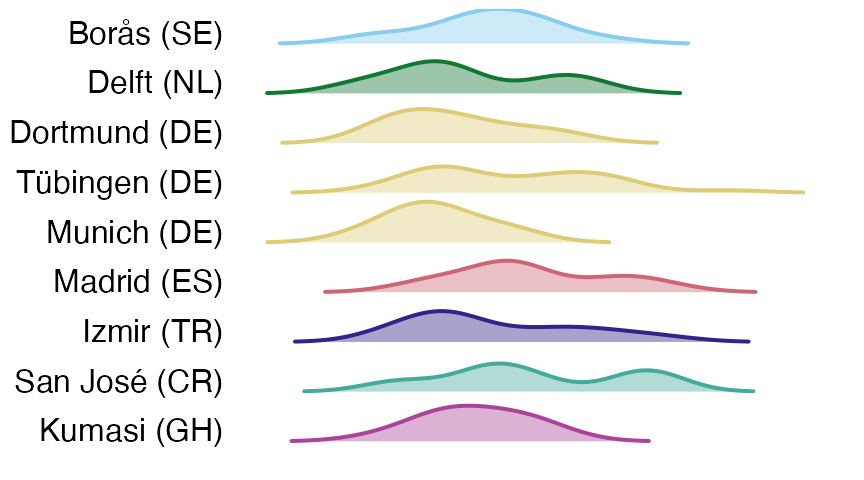

Not supported  
FDR-adjusted p = 0.228  
Part R²: 6.9% [4.1–20.4] (not FDR-supported)

Not supported  
Effect per 1 h: ×0.98 [0.94–1.02]  
FDR-adjusted p = 0.401  
Part R²: 0.4% [0.0–4.6] (not FDR-supported)

Not supported  
Effect per 10°: ×1.01 [0.96–1.06]  
FDR-adjusted p = 0.903  
Part R²: 0.1% [0.0–3.5] (not FDR-supported)

Fixed effects (marginal R²): 15.4% [10.4–30.8]  
Full model (conditional R²): 15.4% [10.4–30.8]  
Participant random-intercept share: Not applicable

*n*<sub>participants</sub> = 141  
*n*<sub>participant-days</sub> = 816  
*n*<sub>observations</sub> = 141  
*n*<sub>sites</sub> = 9

**Intradaily variability**  
Within-day fragmentation of light exposure; higher values indicate less consolidated light–dark input.

**1.253 [0.93–1.502]** —  
*n*<sub>participants</sub> = 141; *n*<sub>participant-days</sub> = 816

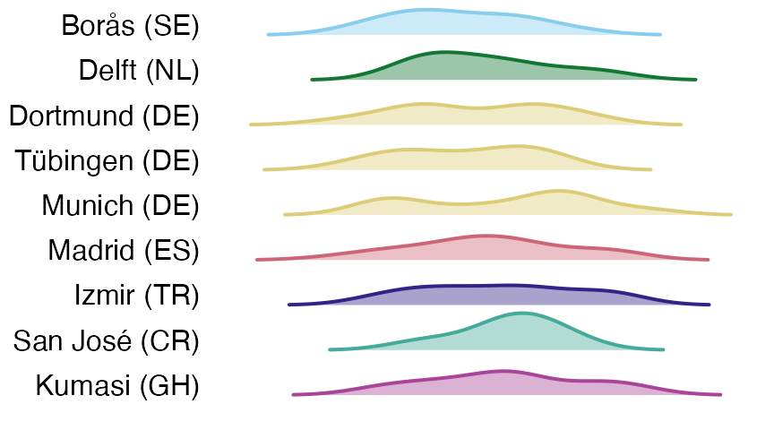

Not supported  
FDR-adjusted p = 0.483  
Part R²: 5.1% [3.8–18.7] (not FDR-supported)

Not supported  
Effect per 1 h: -0.02 [-0.06–0.02]  
FDR-adjusted p = 0.327  
Part R²: 0.7% [0.0–5.7] (not FDR-supported)

Not supported  
Effect per 10°: -0.04 [-0.08–0.01]  
FDR-adjusted p = 0.139  
Part R²: 2.1% [0.0–8.9] (not FDR-supported)

Fixed effects (marginal R²): 5.9% [4.6–21.2]  
Full model (conditional R²): 5.9% [4.6–21.2]  
Participant random-intercept share: Not applicable

*n*<sub>participants</sub> = 141  
*n*<sub>participant-days</sub> = 816  
*n*<sub>observations</sub> = 141  
*n*<sub>sites</sub> = 9

Level

**Mean melEDI**  
Geometric average of daily melEDI values, including zeros; summarizes overall exposure while reducing peak influence.

**5.154 [2.831–9.225]** lx  
*n*<sub>participants</sub> = 141; *n*<sub>participant-days</sub> = 816

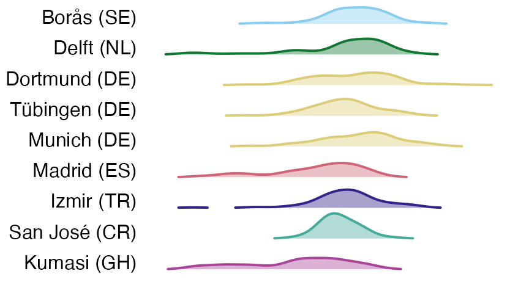

Supported  
**FDR-adjusted p <0.001**  
Part R²: 8.4% [4.8–16.6]

Supported  
Effect per 1 h: ×1.18 [1.11–1.26]  
**FDR-adjusted p <0.001**  
Part R²: 7.7% [2.9–13.9]

Supported  
Effect per 10°: ×1.15 [1.07–1.25]  
**FDR-adjusted p = 0.002**  
Part R²: 3.6% [0.8–8.2]

Fixed effects (marginal R²): 25.4% [18.6–34.4]  
Full model (conditional R²): 57.7% [51.9–65.1]  
Participant random-intercept share: 32.3% [24.5–39.4]

*n*<sub>participants</sub> = 141  
*n*<sub>participant-days</sub> = 816  
*n*<sub>observations</sub> = 816  
*n*<sub>sites</sub> = 9

**Brightest 10 h mean**  
Mean of the brightest 10 hours; reflects the strength of the main daytime light episode.

**110.566 [41.513–243.212]** lx  
*n*<sub>participants</sub> = 141; *n*<sub>participant-days</sub> = 816

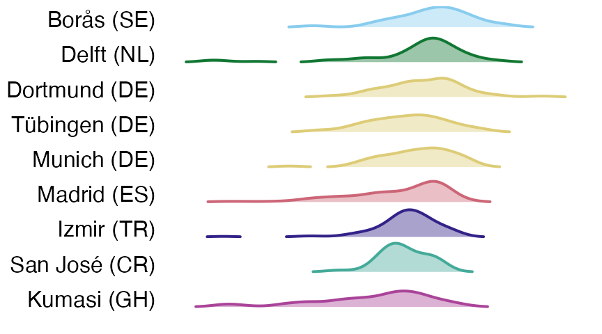

Supported  
**FDR-adjusted p = 0.011**  
Part R²: 5.7% [3.3–12.7]

Supported  
Effect per 1 h: ×1.24 [1.13–1.36]  
**FDR-adjusted p <0.001**  
Part R²: 5.8% [1.9–11.1]

Supported  
Effect per 10°: ×1.24 [1.11–1.39]  
**FDR-adjusted p = 0.001**  
Part R²: 3.6% [0.8–8.1]

Fixed effects (marginal R²): 17.6% [12.1–26.0]  
Full model (conditional R²): 46.0% [39.6–54.3]  
Participant random-intercept share: 28.4% [20.9–35.4]

*n*<sub>participants</sub> = 141  
*n*<sub>participant-days</sub> = 816  
*n*<sub>observations</sub> = 816  
*n*<sub>sites</sub> = 9

**Darkest 10 h mean**  
Mean of the darkest 10 hours; lower values during the biological night favour melatonin preservation and sleep.

**0.103 [0.02–0.253]** lx  
*n*<sub>participants</sub> = 141; *n*<sub>participant-days</sub> = 816

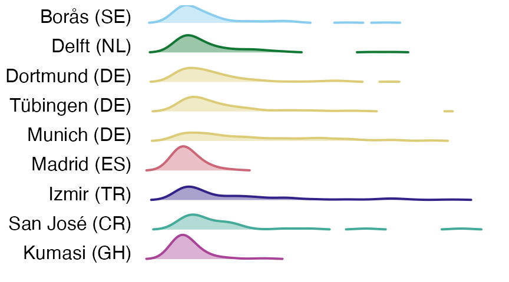

Supported  
**FDR-adjusted p <0.001**  
Part R²: 13.7% [9.2–23.9]

Supported  
Effect per 1 h: ×1.09 [1.03–1.14]  
**FDR-adjusted p = 0.002**  
Part R²: 3.4% [0.5–8.3]

Not supported  
Effect per 10°: ×1.04 [0.97–1.11]  
FDR-adjusted p = 0.400  
Part R²: 0.5% [0.0–3.2] (not FDR-supported)

Fixed effects (marginal R²): 22.0% [15.8–31.8]  
Full model (conditional R²): 61.1% [55.3–68.1]  
Participant random-intercept share: 39.1% [30.4–46.2]

*n*<sub>participants</sub> = 141  
*n*<sub>participant-days</sub> = 816  
*n*<sub>observations</sub> = 816  
*n*<sub>sites</sub> = 9

Duration

**Time above 1,000 lx melEDI**  
Bright-light exposure duration; relevant to daytime alerting and circadian entrainment.

**00:41 [00:11–01:33]** HH:MM  
*n*<sub>participants</sub> = 141; *n*<sub>participant-days</sub> = 816

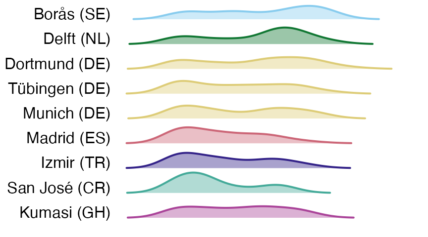

Not supported  
FDR-adjusted p = 0.071  
Part R²: 4.7% [2.6–12.1] (not FDR-supported)

Supported  
Effect per 1 h: ×1.21 [1.13–1.29]  
**FDR-adjusted p <0.001**  
Part R²: 9.0% [3.7–15.7]

Not supported  
Effect per 10°: ×1.03 [0.94–1.12]  
FDR-adjusted p = 0.769  
Part R²: 0.0% [-0.0–2.0] (not FDR-supported)

Fixed effects (marginal R²): 21.5% [16.3–32.3]  
Full model (conditional R²): 50.1% [40.2–57.6]  
Participant random-intercept share: 28.6% [17.7–34.2]

*n*<sub>participants</sub> = 141  
*n*<sub>participant-days</sub> = 816  
*n*<sub>observations</sub> = 816  
*n*<sub>sites</sub> = 9

**Time above 250 lx melEDI during wake**  
Waking time in recommended daytime light; relevant to alertness, entrainment, and subsequent sleep.

**02:25 [00:51–04:37]** HH:MM  
*n*<sub>participants</sub> = 141; *n*<sub>participant-days</sub> = 737

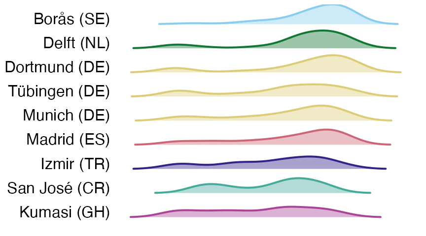

Supported  
**FDR-adjusted p = 0.007**  
Part R²: 8.6% [5.2–18.7]

Supported  
Effect per 1 h: ×1.14 [1.07–1.20]  
**FDR-adjusted p <0.001**  
Part R²: 6.4% [2.0–12.7]

Supported  
Effect per 10°: ×1.12 [1.04–1.20]  
**FDR-adjusted p = 0.013**  
Part R²: 3.1% [0.3–8.3]

Fixed effects (marginal R²): 18.0% [12.9–29.1]  
Full model (conditional R²): 50.1% [41.6–58.0]  
Participant random-intercept share: 32.1% [20.7–36.7]

*n*<sub>participants</sub> = 141  
*n*<sub>participant-days</sub> = 737  
*n*<sub>observations</sub> = 737  
*n*<sub>sites</sub> = 9

**Time below 10 lx melEDI before sleep**  
Low-light time before bed; limits evening melatonin suppression and circadian delay.

**01:53 [01:01–02:35]** HH:MM  
*n*<sub>participants</sub> = 139; *n*<sub>participant-days</sub> = 655

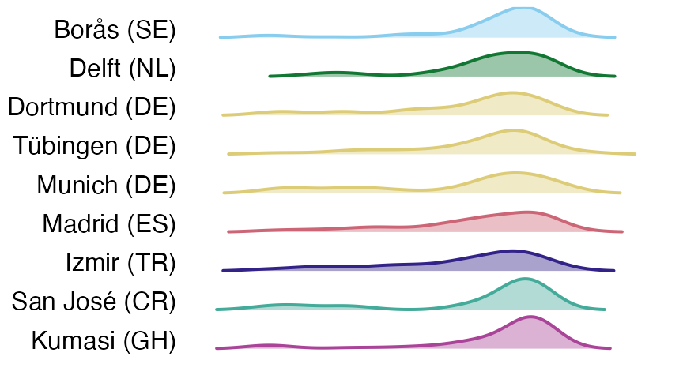

Supported  
**FDR-adjusted p = 0.049**  
Part R²: 5.4% [3.2–13.4]

Supported  
Effect per 1 h: -0.13 [-0.20–-0.07] h  
**FDR-adjusted p <0.001**  
Part R²: 4.9% [1.2–10.5]

Not supported  
Effect per 10°: 0.00 [-0.09–0.09] h  
FDR-adjusted p = 0.962  
Part R²: 0.0% [0.0–1.7] (not FDR-supported)

Fixed effects (marginal R²): 7.6% [4.6–17.2]  
Full model (conditional R²): 38.3% [31.8–48.5]  
Participant random-intercept share: 30.7% [21.7–38.1]

*n*<sub>participants</sub> = 139  
*n*<sub>participant-days</sub> = 655  
*n*<sub>observations</sub> = 655  
*n*<sub>sites</sub> = 9

**Time below 1 lx melEDI during sleep**  
Darkness during sleep; supports nocturnal melatonin and an undisturbed sleep environment.

**07:08 [05:58–08:15]** HH:MM  
*n*<sub>participants</sub> = 141; *n*<sub>participant-days</sub> = 778

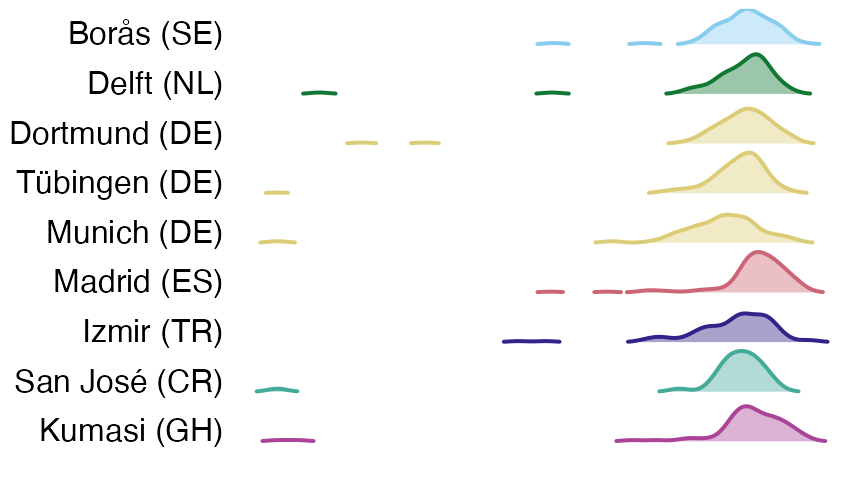

Not supported  
FDR-adjusted p = 0.058  
Part R²: 5.4% [3.2–14.2] (not FDR-supported)

Not supported  
Effect per 1 h: ×0.99 [0.97–1.01]  
FDR-adjusted p = 0.227  
Part R²: 0.6% [0.0–3.8] (not FDR-supported)

Not supported  
Effect per 10°: ×1.00 [0.97–1.02]  
FDR-adjusted p = 0.903  
Part R²: 0.0% [0.0–1.6] (not FDR-supported)

Fixed effects (marginal R²): 8.0% [5.1–18.2]  
Full model (conditional R²): 40.9% [32.8–48.5]  
Participant random-intercept share: 32.9% [22.0–37.8]

*n*<sub>participants</sub> = 141  
*n*<sub>participant-days</sub> = 778  
*n*<sub>observations</sub> = 778  
*n*<sub>sites</sub> = 9

**Longest continuous period above 250 lx melEDI**  
Longest sustained bright-light bout; captures continuity of daytime circadian stimulation.

**00:38 [00:17–01:12]** HH:MM  
*n*<sub>participants</sub> = 141; *n*<sub>participant-days</sub> = 816

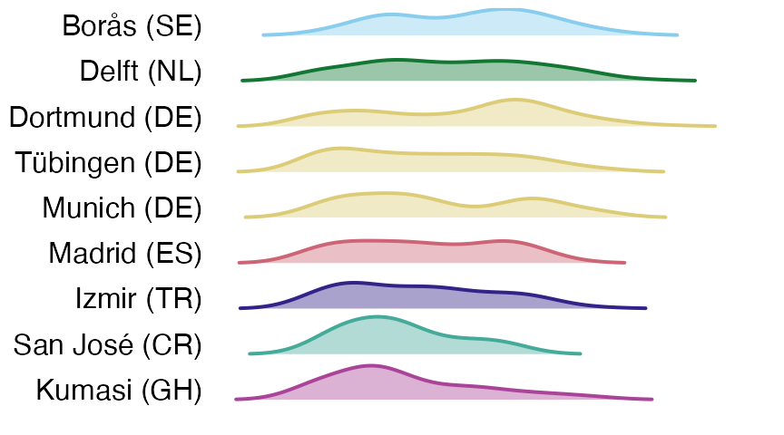

Not supported  
FDR-adjusted p = 0.398  
Part R²: 2.2% [1.4–8.1] (not FDR-supported)

Supported  
Effect per 1 h: ×1.12 [1.07–1.19]  
**FDR-adjusted p <0.001**  
Part R²: 4.9% [1.3–9.6]

Not supported  
Effect per 10°: ×1.06 [0.99–1.13]  
FDR-adjusted p = 0.139  
Part R²: 0.8% [0.0–3.4] (not FDR-supported)

Fixed effects (marginal R²): 10.0% [6.1–17.9]  
Full model (conditional R²): 36.3% [29.9–45.3]  
Participant random-intercept share: 26.3% [18.7–33.0]

*n*<sub>participants</sub> = 141  
*n*<sub>participant-days</sub> = 816  
*n*<sub>observations</sub> = 816  
*n*<sub>sites</sub> = 9

Timing

**Midpoint of the brightest 10 hours**  
Centre time of the brightest 10 hours; indexes the main daily circadian light cue.

**13:44 [12:48–15:00]** HH:MM clock time  
*n*<sub>participants</sub> = 141; *n*<sub>participant-days</sub> = 816

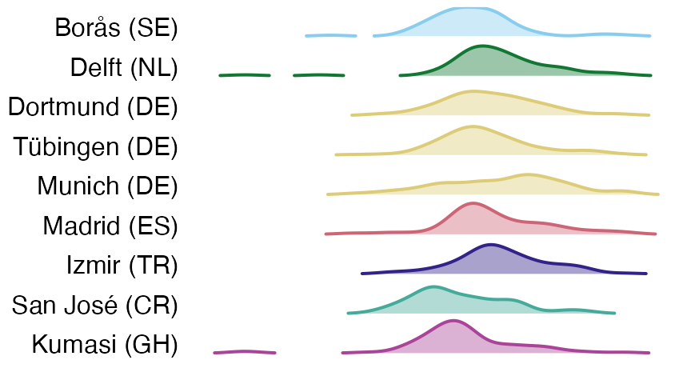

Supported  
**FDR-adjusted p <0.001**  
Part R²: 6.5% [4.4–12.6]

Not supported  
Effect per 1 h: 0.05 [-0.05–0.15] h  
FDR-adjusted p = 0.305  
Part R²: 0.2% [0.0–1.8] (not FDR-supported)

Supported  
Effect per 10°: 0.19 [0.06–0.32] h  
**FDR-adjusted p = 0.013**  
Part R²: 1.9% [0.2–5.0]

Fixed effects (marginal R²): 6.7% [4.6–13.0]  
Full model (conditional R²): 22.9% [16.9–31.6]  
Participant random-intercept share: 16.2% [9.6–22.4]

*n*<sub>participants</sub> = 141  
*n*<sub>participant-days</sub> = 816  
*n*<sub>observations</sub> = 816  
*n*<sub>sites</sub> = 9

**Midpoint of the darkest 10 hours**  
Centre time of the darkest 10 hours; indexes the main daily darkness cue.

**02:54 [02:01–03:50]** HH:MM clock time  
*n*<sub>participants</sub> = 141; *n*<sub>participant-days</sub> = 816

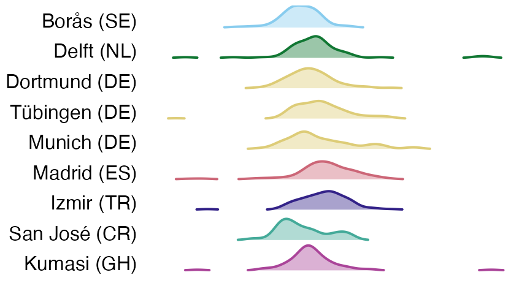

Supported  
**FDR-adjusted p = 0.020**  
Part R²: 4.6% [3.0–10.5]

Supported  
Effect per 1 h: -0.15 [-0.25–-0.05] h  
**FDR-adjusted p = 0.004**  
Part R²: 2.1% [0.3–5.6]

Not supported  
Effect per 10°: 0.12 [-0.00–0.24] h  
FDR-adjusted p = 0.114  
Part R²: 0.9% [0.0–3.4] (not FDR-supported)

Fixed effects (marginal R²): 8.6% [5.9–15.8]  
Full model (conditional R²): 28.2% [22.1–36.7]  
Participant random-intercept share: 19.6% [12.6–25.8]

*n*<sub>participants</sub> = 141  
*n*<sub>participant-days</sub> = 816  
*n*<sub>observations</sub> = 816  
*n*<sub>sites</sub> = 9

**Mean timing of exposure above 250 lx melEDI**  
Average bright-light timing; summarizes the phase of daily circadian stimulation.

**13:29 [12:29–14:39]** HH:MM clock time  
*n*<sub>participants</sub> = 141; *n*<sub>participant-days</sub> = 742

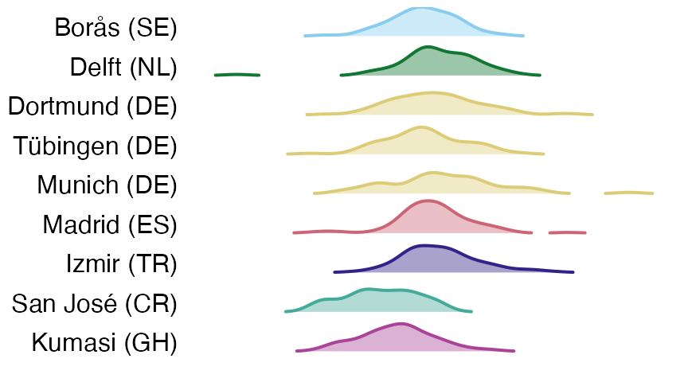

Supported  
**FDR-adjusted p <0.001**  
Part R²: 12.7% [9.4–19.2]

Supported  
Effect per 1 h: 0.12 [0.03–0.21] h  
**FDR-adjusted p = 0.013**  
Part R²: 1.2% [0.1–3.6]

Supported  
Effect per 10°: 0.33 [0.21–0.46] h  
**FDR-adjusted p <0.001**  
Part R²: 6.0% [2.7–9.7]

Fixed effects (marginal R²): 14.7% [10.7–21.9]  
Full model (conditional R²): 25.7% [19.8–34.2]  
Participant random-intercept share: 11.0% [5.3–17.2]

*n*<sub>participants</sub> = 141  
*n*<sub>participant-days</sub> = 742  
*n*<sub>observations</sub> = 742  
*n*<sub>sites</sub> = 9

**First light timing above 250 lx melEDI**  
First waking bright-light exposure; morning timing can advance circadian phase and promote alertness.

**09:08 [08:02–10:40]** HH:MM clock time  
*n*<sub>participants</sub> = 140; *n*<sub>participant-days</sub> = 727

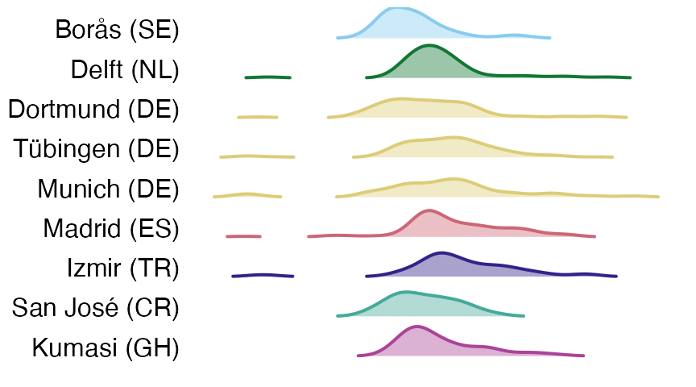

Not supported  
FDR-adjusted p = 0.112  
Part R²: 3.8% [2.3–10.2] (not FDR-supported)

Not supported  
Effect per 1 h: -0.10 [-0.25–0.05] h  
FDR-adjusted p = 0.227  
Part R²: 0.5% [0.0–2.8] (not FDR-supported)

Not supported  
Effect per 10°: 0.02 [-0.17–0.21] h  
FDR-adjusted p = 0.903  
Part R²: 0.0% [-0.0–1.3] (not FDR-supported)

Fixed effects (marginal R²): 6.8% [4.4–14.4]  
Full model (conditional R²): 31.0% [24.6–40.5]  
Participant random-intercept share: 24.2% [16.2–31.5]

*n*<sub>participants</sub> = 140  
*n*<sub>participant-days</sub> = 727  
*n*<sub>observations</sub> = 727  
*n*<sub>sites</sub> = 9

**Last light timing above 250 lx melEDI**  
Last bright-light exposure; later timing may delay circadian phase and sleep onset.

**18:08 [16:27–19:42]** HH:MM clock time  
*n*<sub>participants</sub> = 141; *n*<sub>participant-days</sub> = 687

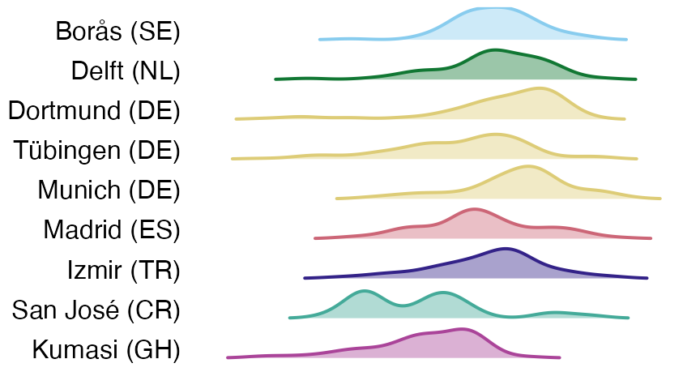

Supported  
**FDR-adjusted p <0.001**  
Part R²: 11.6% [8.3–18.6]

Supported  
Effect per 1 h: 0.32 [0.19–0.46] h  
**FDR-adjusted p <0.001**  
Part R²: 4.5% [1.5–8.5]

Supported  
Effect per 10°: 0.46 [0.27–0.64] h  
**FDR-adjusted p <0.001**  
Part R²: 5.7% [2.2–9.9]

Fixed effects (marginal R²): 22.2% [17.0–30.2]  
Full model (conditional R²): 37.9% [31.6–46.3]  
Participant random-intercept share: 15.8% [9.7–22.3]

*n*<sub>participants</sub> = 141  
*n*<sub>participant-days</sub> = 687  
*n*<sub>observations</sub> = 687  
*n*<sub>sites</sub> = 9

Exposure history

**melEDI dose**  
Intensity–duration-weighted melanopic exposure; summarizes cumulative non-visual retinal light input.

**4.96 [1.936–12.313]** klx·h  
*n*<sub>participants</sub> = 141; *n*<sub>participant-days</sub> = 761

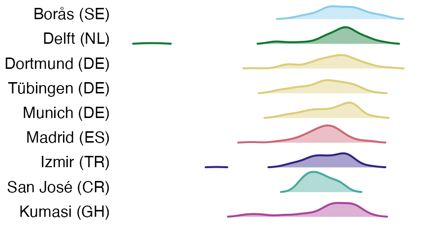

Not supported  
FDR-adjusted p = 0.209  
Part R²: 2.8% [1.7–8.6] (not FDR-supported)

Supported  
Effect per 1 h: ×1.28 [1.17–1.39]  
**FDR-adjusted p <0.001**  
Part R²: 7.5% [3.1–12.9]

Not supported  
Effect per 10°: ×1.02 [0.91–1.13]  
FDR-adjusted p = 0.903  
Part R²: 0.0% [-0.0–1.2] (not FDR-supported)

Fixed effects (marginal R²): 11.8% [7.7–19.7]  
Full model (conditional R²): 33.8% [26.7–42.8]  
Participant random-intercept share: 22.0% [14.5–28.7]

*n*<sub>participants</sub> = 141  
*n*<sub>participant-days</sub> = 761  
*n*<sub>observations</sub> = 761  
*n*<sub>sites</sub> = 9

Spectrum

**Melanopic daylight efficacy ratio**  
Mean of viable one-minute melEDI/illuminance ratios; indicates melanopic efficacy relative to visual light.

**0.724 [0.643–0.795]** —  
*n*<sub>participants</sub> = 137; *n*<sub>participant-days</sub> = 687

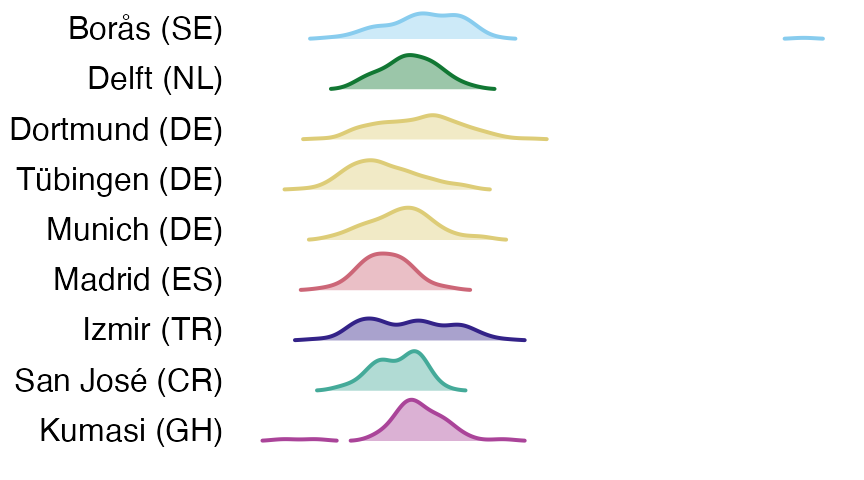

Supported  
**FDR-adjusted p <0.001**  
Part R²: 9.6% [6.0–17.8]

Supported  
Effect per 1 h: 0.02 [0.02–0.03]  
**FDR-adjusted p <0.001**  
Part R²: 13.0% [6.7–20.6]

Supported  
Effect per 10°: -0.01 [-0.02–-0.00]  
**FDR-adjusted p = 0.013**  
Part R²: 2.7% [0.3–6.9]

Fixed effects (marginal R²): 27.8% [21.3–38.1]  
Full model (conditional R²): 60.5% [54.6–68.2]  
Participant random-intercept share: 32.7% [24.1–40.0]

*n*<sub>participants</sub> = 137  
*n*<sub>participant-days</sub> = 702  
*n*<sub>observations</sub> = 702  
*n*<sub>sites</sub> = 9

Overall values are medians [interquartile ranges] from the accepted near-eye descriptive dataset; their participant and participant-day counts are therefore shown separately from each model’s exact fitted sample. Participant-days equal observations for the 15 participant-day models. The two participant-level dynamics models use one observation per participant, with participant-days giving the contributing repeated-day support. All primary models use nine sites. Bold FDR-adjusted p-values meet the p < 0.050 rule within the explicitly labelled complete 17-test family. Grey part R² values are shown for context but their corresponding term was not FDR-supported. Site, photoperiod, and latitude part R² values can overlap and must not be summed. Marginal R² represents fixed effects, conditional R² represents the full model, and the participant random-intercept share is conditional minus marginal R². Its 95% CIs and all other R² CIs use 1,000 successful joint bootstrap refits. Density thumbnails use metric-specific display scales and preserve the registered site order and colours; display transformations do not alter source values.

Source data for Table 1 and accepted metric-level distribution source

The compact synthesis above is followed by a wider inferential summary that retains the four complete 17-test family decisions and their exact fitted samples without the descriptive context.

Table 2: Primary near-eye site, photoperiod, latitude, and site-versus-latitude results.

|  | Overall site FDR-adjusted p | Photoperiod Photoperiod effect (95% CI) | Photoperiod Photoperiod FDR-adjusted p | Latitude Latitude effect per 10° (95% CI) | Latitude Latitude FDR-adjusted p | Site-versus-latitude FDR-adjusted p | Exact fitted sample |  |  |
| --- | --- | --- | --- | --- | --- | --- | --- | --- | --- |
| Dynamics |  |  |  |  |  |  |  |  |  |
| Interdaily stability | 0.228 | ×0.98 [0.94–1.02] | 0.401 | ×1.01 [0.96–1.06] | 0.903 |  |  | 0.175 | *n*<sub>participants</sub> = 141; *n*<sub>participant-days</sub> = 816 |
| Intradaily variability | 0.483 | -0.02 [-0.06–0.02] | 0.327 | -0.04 [-0.08–0.01] | 0.139 | 0.723 | *n*<sub>participants</sub> = 141; *n*<sub>participant-days</sub> = 816 |  |  |
| Level |  |  |  |  |  |  |  |  |  |
| Mean melEDI | <0.001 | ×1.18 [1.11–1.26] | <0.001 | ×1.15 [1.07–1.25] | 0.002 | 0.032 | *n*<sub>participants</sub> = 141; *n*<sub>participant-days</sub> = 816 |  |  |
| Brightest 10 h mean | 0.011 | ×1.24 [1.13–1.36] | <0.001 | ×1.24 [1.11–1.39] | 0.001 | 0.325 | *n*<sub>participants</sub> = 141; *n*<sub>participant-days</sub> = 816 |  |  |
| Darkest 10 h mean | <0.001 | ×1.09 [1.03–1.14] | 0.002 | ×1.04 [0.97–1.11] | 0.400 | <0.001 | *n*<sub>participants</sub> = 141; *n*<sub>participant-days</sub> = 816 |  |  |
| Duration |  |  |  |  |  |  |  |  |  |
| Time above 1,000 lx melEDI | 0.071 | ×1.21 [1.13–1.29] | <0.001 | ×1.03 [0.94–1.12] | 0.769 | 0.053 | *n*<sub>participants</sub> = 141; *n*<sub>participant-days</sub> = 816 |  |  |
| Time above 250 lx melEDI during wake | 0.007 | ×1.14 [1.07–1.20] | <0.001 | ×1.12 [1.04–1.20] | 0.013 | 0.053 | *n*<sub>participants</sub> = 141; *n*<sub>participant-days</sub> = 737 |  |  |
| Time below 10 lx melEDI before sleep | 0.049 | -0.13 [-0.20–-0.07] h | <0.001 | 0.00 [-0.09–0.09] h | 0.962 | 0.040 | *n*<sub>participants</sub> = 139; *n*<sub>participant-days</sub> = 655 |  |  |
| Time below 1 lx melEDI during sleep | 0.058 | ×0.99 [0.97–1.01] | 0.227 | ×1.00 [0.97–1.02] | 0.903 | 0.043 | *n*<sub>participants</sub> = 141; *n*<sub>participant-days</sub> = 778 |  |  |
| Longest continuous period above 250 lx melEDI | 0.398 | ×1.12 [1.07–1.19] | <0.001 | ×1.06 [0.99–1.13] | 0.139 | 0.626 | *n*<sub>participants</sub> = 141; *n*<sub>participant-days</sub> = 816 |  |  |
| Timing |  |  |  |  |  |  |  |  |  |
| Midpoint of the brightest 10 hours | <0.001 | 0.05 [-0.05–0.15] h | 0.305 | 0.19 [0.06–0.32] h | 0.013 | 0.010 | *n*<sub>participants</sub> = 141; *n*<sub>participant-days</sub> = 816 |  |  |
| Midpoint of the darkest 10 hours | 0.020 | -0.15 [-0.25–-0.05] h | 0.004 | 0.12 [-0.00–0.24] h | 0.114 | 0.043 | *n*<sub>participants</sub> = 141; *n*<sub>participant-days</sub> = 816 |  |  |
| Mean timing of exposure above 250 lx melEDI | <0.001 | 0.12 [0.03–0.21] h | 0.013 | 0.33 [0.21–0.46] h | <0.001 | <0.001 | *n*<sub>participants</sub> = 141; *n*<sub>participant-days</sub> = 742 |  |  |
| First light timing above 250 lx melEDI | 0.112 | -0.10 [-0.25–0.05] h | 0.227 | 0.02 [-0.17–0.21] h | 0.903 | 0.077 | *n*<sub>participants</sub> = 140; *n*<sub>participant-days</sub> = 727 |  |  |
| Last light timing above 250 lx melEDI | <0.001 | 0.32 [0.19–0.46] h | <0.001 | 0.46 [0.27–0.64] h | <0.001 | <0.001 | *n*<sub>participants</sub> = 141; *n*<sub>participant-days</sub> = 687 |  |  |
| Exposure history |  |  |  |  |  |  |  |  |  |
| melEDI dose | 0.209 | ×1.28 [1.17–1.39] | <0.001 | ×1.02 [0.91–1.13] | 0.903 | 0.156 | *n*<sub>participants</sub> = 141; *n*<sub>participant-days</sub> = 761 |  |  |
| Spectrum |  |  |  |  |  |  |  |  |  |
| Melanopic daylight efficacy ratio | <0.001 | 0.02 [0.02–0.03] | <0.001 | -0.01 [-0.02–-0.00] | 0.013 | 0.010 | *n*<sub>participants</sub> = 137; *n*<sub>participant-days</sub> = 702 |  |  |

This summary combines the model-level decisions, photoperiod and latitude effects, 95% CIs, and exact fitted samples. Each displayed p-value is FDR-adjusted within its explicitly labelled complete 17-test family; bold values meet the FDR-adjusted p < 0.050 rule. Full raw p-values and test statistics remain in the detailed tables below. Exact fitted samples use italic n with participant and participant-day subscripts. For the 15 participant-day models, the participant-day count equals the number of fitted observations. The two participant-level dynamics models use one fitted observation per participant and retain the participant-day count as contributing repeated-day support. All models include nine sites.

## Primary near-eye results

### Model-level tests

Table 3: Primary near-eye model-level tests with raw and FDR-adjusted p-values.

|  | Overall site Statistic (df) | Overall site Raw p | Overall site FDR-adjusted p | Photoperiod Statistic (df) | Photoperiod Raw p | Photoperiod FDR-adjusted p | Latitude Statistic (df) | Latitude Raw p | Latitude FDR-adjusted p | Site versus linear latitude Statistic (df) | Site versus linear latitude Raw p | Site versus linear latitude FDR-adjusted p |
| --- | --- | --- | --- | --- | --- | --- | --- | --- | --- | --- | --- | --- |
| Dynamics |  |  |  |  |  |  |  |  |  |  |  |  |
| Interdaily stability | 11.01 (df 8) | 0.201 | 0.228 | 0.70 (df 1) | 0.401 | 0.401 | 0.14 (df 1) | 0.712 | 0.903 | 10.87 (df 7) | 0.144 | 0.175 |
| Intradaily variability | 7.51 (df 8) | 0.483 | 0.483 | 1.04 (df 1) | 0.308 | 0.327 | 3.02 (df 1) | 0.082 | 0.139 | 4.48 (df 7) | 0.723 | 0.723 |
| Level |  |  |  |  |  |  |  |  |  |  |  |  |
| Mean melEDI | 30.60 (df 8) | <0.001 | <0.001 | 26.75 (df 1) | <0.001 | <0.001 | 12.41 (df 1) | <0.001 | 0.002 | 18.19 (df 7) | 0.011 | 0.032 |
| Brightest 10 h mean | 21.98 (df 8) | 0.005 | 0.011 | 21.24 (df 1) | <0.001 | <0.001 | 13.43 (df 1) | <0.001 | 0.001 | 8.54 (df 7) | 0.287 | 0.325 |
| Darkest 10 h mean | 40.71 (df 8) | <0.001 | <0.001 | 10.90 (df 1) | <0.001 | 0.002 | 1.28 (df 1) | 0.259 | 0.400 | 39.43 (df 7) | <0.001 | <0.001 |
| Duration |  |  |  |  |  |  |  |  |  |  |  |  |
| Time above 1,000 lx melEDI | 15.51 (df 8) | 0.050 | 0.071 | 27.41 (df 1) | <0.001 | <0.001 | 0.37 (df 1) | 0.543 | 0.769 | 15.14 (df 7) | 0.034 | 0.053 |
| Time above 250 lx melEDI during wake | 23.25 (df 8) | 0.003 | 0.007 | 17.73 (df 1) | <0.001 | <0.001 | 7.96 (df 1) | 0.005 | 0.013 | 15.30 (df 7) | 0.032 | 0.053 |
| Time below 10 lx melEDI before sleep | 17.14 (df 8) | 0.029 | 0.049 | 15.41 (df 1) | <0.001 | <0.001 | 0.00 (df 1) | 0.962 | 0.962 | 17.14 (df 7) | 0.017 | 0.040 |
| Time below 1 lx melEDI during sleep | 16.38 (df 8) | 0.037 | 0.058 | 1.85 (df 1) | 0.174 | 0.227 | 0.04 (df 1) | 0.850 | 0.903 | 16.34 (df 7) | 0.022 | 0.043 |
| Longest continuous period above 250 lx melEDI | 8.63 (df 8) | 0.375 | 0.398 | 18.14 (df 1) | <0.001 | <0.001 | 3.04 (df 1) | 0.081 | 0.139 | 5.59 (df 7) | 0.589 | 0.626 |
| Timing |  |  |  |  |  |  |  |  |  |  |  |  |
| Midpoint of the brightest 10 hours | 30.01 (df 8) | <0.001 | <0.001 | 1.22 (df 1) | 0.269 | 0.305 | 8.33 (df 1) | 0.004 | 0.013 | 21.68 (df 7) | 0.003 | 0.010 |
| Midpoint of the darkest 10 hours | 19.96 (df 8) | 0.010 | 0.020 | 9.21 (df 1) | 0.002 | 0.004 | 3.72 (df 1) | 0.054 | 0.114 | 16.24 (df 7) | 0.023 | 0.043 |
| Mean timing of exposure above 250 lx melEDI | 62.56 (df 8) | <0.001 | <0.001 | 6.86 (df 1) | 0.009 | 0.013 | 26.07 (df 1) | <0.001 | <0.001 | 36.49 (df 7) | <0.001 | <0.001 |
| First light timing above 250 lx melEDI | 13.86 (df 8) | 0.086 | 0.112 | 1.74 (df 1) | 0.187 | 0.227 | 0.04 (df 1) | 0.834 | 0.903 | 13.81 (df 7) | 0.055 | 0.077 |
| Last light timing above 250 lx melEDI | 51.99 (df 8) | <0.001 | <0.001 | 21.37 (df 1) | <0.001 | <0.001 | 23.01 (df 1) | <0.001 | <0.001 | 28.98 (df 7) | <0.001 | <0.001 |
| Exposure history |  |  |  |  |  |  |  |  |  |  |  |  |
| melEDI dose | 11.56 (df 8) | 0.172 | 0.209 | 29.24 (df 1) | <0.001 | <0.001 | 0.08 (df 1) | 0.771 | 0.903 | 11.48 (df 7) | 0.119 | 0.156 |
| Spectrum |  |  |  |  |  |  |  |  |  |  |  |  |
| Melanopic daylight efficacy ratio | 29.86 (df 8) | <0.001 | <0.001 | 39.50 (df 1) | <0.001 | <0.001 | 7.82 (df 1) | 0.005 | 0.013 | 22.03 (df 7) | 0.003 | 0.010 |

Bold FDR-adjusted p-values meet the declared FDR-adjusted p < 0.050 decision rule in their separate 17-test family. Raw p-values have no separate decision rule here and are not bold.

### Photoperiod and latitude effects

Table 4: Primary near-eye photoperiod and latitude effects, 95% CIs, raw and FDR-adjusted p-values, and exact fitted samples.

|  | Photoperiod Effect (95% CI) | Photoperiod Raw p | Photoperiod FDR-adjusted p | Latitude Effect per 10° (95% CI) | Latitude Raw p | Latitude FDR-adjusted p | Exact fitted sample Participants | Exact fitted sample Participant-days | Exact fitted sample Observations | Exact fitted sample Sites |
| --- | --- | --- | --- | --- | --- | --- | --- | --- | --- | --- |
| Dynamics |  |  |  |  |  |  |  |  |  |  |
| Interdaily stability | ×0.98 [0.94–1.02] | 0.418 | 0.401 | ×1.01 [0.96–1.06] | 0.715 | 0.903 | 141 | 816 | 141 | 9 |
| Intradaily variability | -0.02 [-0.06–0.02] | 0.325 | 0.327 | -0.04 [-0.08–0.01] | 0.084 | 0.139 | 141 | 816 | 141 | 9 |
| Level |  |  |  |  |  |  |  |  |  |  |
| Mean melEDI | ×1.18 [1.11–1.26] | <0.001 | <0.001 | ×1.15 [1.07–1.25] | <0.001 | 0.002 | 141 | 816 | 816 | 9 |
| Brightest 10 h mean | ×1.24 [1.13–1.36] | <0.001 | <0.001 | ×1.24 [1.11–1.39] | <0.001 | 0.001 | 141 | 816 | 816 | 9 |
| Darkest 10 h mean | ×1.09 [1.03–1.14] | 0.001 | 0.002 | ×1.04 [0.97–1.11] | 0.263 | 0.400 | 141 | 816 | 816 | 9 |
| Duration |  |  |  |  |  |  |  |  |  |  |
| Time above 1,000 lx melEDI | ×1.21 [1.13–1.29] | <0.001 | <0.001 | ×1.03 [0.94–1.12] | 0.542 | 0.769 | 141 | 816 | 816 | 9 |
| Time above 250 lx melEDI during wake | ×1.14 [1.07–1.20] | <0.001 | <0.001 | ×1.12 [1.04–1.20] | 0.004 | 0.013 | 141 | 737 | 737 | 9 |
| Time below 10 lx melEDI before sleep | -0.13 [-0.20–-0.07] h | <0.001 | <0.001 | 0.00 [-0.09–0.09] h | 0.963 | 0.962 | 139 | 655 | 655 | 9 |
| Time below 1 lx melEDI during sleep | ×0.99 [0.97–1.01] | 0.173 | 0.227 | ×1.00 [0.97–1.02] | 0.850 | 0.903 | 141 | 778 | 778 | 9 |
| Longest continuous period above 250 lx melEDI | ×1.12 [1.07–1.19] | <0.001 | <0.001 | ×1.06 [0.99–1.13] | 0.083 | 0.139 | 141 | 816 | 816 | 9 |
| Timing |  |  |  |  |  |  |  |  |  |  |
| Midpoint of the brightest 10 hours | 0.05 [-0.05–0.15] h | 0.286 | 0.305 | 0.19 [0.06–0.32] h | 0.004 | 0.013 | 141 | 816 | 816 | 9 |
| Midpoint of the darkest 10 hours | -0.15 [-0.25–-0.05] h | 0.003 | 0.004 | 0.12 [-0.00–0.24] h | 0.055 | 0.114 | 141 | 816 | 816 | 9 |
| Mean timing of exposure above 250 lx melEDI | 0.12 [0.03–0.21] h | 0.010 | 0.013 | 0.33 [0.21–0.46] h | <0.001 | <0.001 | 141 | 742 | 742 | 9 |
| First light timing above 250 lx melEDI | -0.10 [-0.25–0.05] h | 0.206 | 0.227 | 0.02 [-0.17–0.21] h | 0.835 | 0.903 | 140 | 727 | 727 | 9 |
| Last light timing above 250 lx melEDI | 0.32 [0.19–0.46] h | <0.001 | <0.001 | 0.46 [0.27–0.64] h | <0.001 | <0.001 | 141 | 687 | 687 | 9 |
| Exposure history |  |  |  |  |  |  |  |  |  |  |
| melEDI dose | ×1.28 [1.17–1.39] | <0.001 | <0.001 | ×1.02 [0.91–1.13] | 0.773 | 0.903 | 141 | 761 | 761 | 9 |
| Spectrum |  |  |  |  |  |  |  |  |  |  |
| Melanopic daylight efficacy ratio | 0.02 [0.02–0.03] | <0.001 | <0.001 | -0.01 [-0.02–-0.00] | 0.005 | 0.013 | 137 | 702 | 702 | 9 |

Effects are differences for identity-scale outcomes, ratios for log-link or log-transformed outcomes, and odds ratios for logit-transformed outcomes; timing differences are hours. Bold FDR-adjusted p-values meet the declared FDR-adjusted p < 0.050 decision rule in the applicable 17-test family. Raw p-values have no separate decision rule here and are not bold.

### Hierarchical site contrasts

[figure not shown]

Figure 2: Primary near-eye site differences or ratios relative to the site-average estimate, which gives each site equal weight. Only metrics with a supported overall site test are shown. Panel A contains ratios and panel B contains differences. Every metric facet uses a symmetric scale around its null, placing 1 for ratios and 0 for differences at the same horizontal position. Filled circles with thicker 95% CIs denote within-metric FDR-adjusted p below 0.050; open circles with thinner intervals denote FDR-adjusted p at least 0.050. Site labels give exact fitted observations as n.

Source data for Figure 2

Table 5: Primary near-eye site-specific deviations for metrics with a supported overall site test.

|  | Deviation from the site-average estimate (95% CI) Borås (SE) | Deviation from the site-average estimate (95% CI) Delft (NL) | Deviation from the site-average estimate (95% CI) Dortmund (DE) | Deviation from the site-average estimate (95% CI) Tübingen (DE) | Deviation from the site-average estimate (95% CI) Munich (DE) | Deviation from the site-average estimate (95% CI) Madrid (ES) | Deviation from the site-average estimate (95% CI) Izmir (TR) | Deviation from the site-average estimate (95% CI) San José (CR) | Deviation from the site-average estimate (95% CI) Kumasi (GH) |
| --- | --- | --- | --- | --- | --- | --- | --- | --- | --- |
| Mean melEDI | ×1.03 [0.72–1.47] | ×0.96 [0.68–1.34] | ×0.92 [0.66–1.28] | **×1.46 [1.12–1.92]** | ×1.00 [0.66–1.51] | ×1.00 [0.72–1.39] | ×1.41 [1.04–1.92] | ×1.10 [0.68–1.77] | **×0.49 [0.35–0.68]** |
| Brightest 10 h mean | ×1.46 [0.87–2.48] | ×1.08 [0.65–1.78] | ×0.97 [0.59–1.57] | ×1.40 [0.94–2.10] | ×0.70 [0.38–1.29] | ×1.39 [0.86–2.26] | ×1.19 [0.75–1.86] | ×0.99 [0.49–2.03] | **×0.41 [0.25–0.66]** |
| Darkest 10 h mean | ×0.75 [0.56–1.00] | ×0.88 [0.67–1.15] | ×0.84 [0.65–1.10] | **×1.36 [1.09–1.69]** | ×1.35 [0.96–1.89] | ×0.76 [0.58–0.99] | **×1.49 [1.16–1.91]** | ×1.30 [0.88–1.93] | **×0.67 [0.51–0.88]** |
| Time above 250 lx melEDI during wake | ×1.24 [0.90–1.70] | ×1.20 [0.88–1.64] | ×0.98 [0.73–1.32] | ×1.12 [0.87–1.43] | ×0.73 [0.50–1.06] | **×1.68 [1.24–2.26]** | ×0.86 [0.65–1.14] | ×0.75 [0.48–1.18] | ×0.78 [0.57–1.06] |
| Time below 10 lx melEDI before sleep | 0.45 [0.08–0.83] h | 0.30 [-0.09–0.69] h | 0.13 [-0.22–0.49] h | -0.23 [-0.51–0.06] h | 0.27 [-0.17–0.71] h | **-0.47 [-0.82–-0.12] h** | **-0.45 [-0.78–-0.12] h** | -0.10 [-0.62–0.42] h | 0.09 [-0.29–0.46] h |
| Midpoint of the brightest 10 hours | -0.58 [-1.15–-0.02] h | 0.38 [-0.16–0.91] h | 0.04 [-0.48–0.57] h | 0.13 [-0.30–0.56] h | 0.48 [-0.17–1.14] h | 0.51 [-0.01–1.03] h | **0.66 [0.17–1.14] h** | -0.84 [-1.61–-0.07] h | **-0.78 [-1.31–-0.24] h** |
| Midpoint of the darkest 10 hours | -0.55 [-1.11–0.00] h | 0.31 [-0.21–0.84] h | 0.12 [-0.40–0.63] h | 0.10 [-0.33–0.52] h | 0.79 [0.15–1.44] h | 0.12 [-0.39–0.63] h | 0.35 [-0.12–0.83] h | -0.80 [-1.55–-0.04] h | -0.45 [-0.97–0.07] h |
| Mean timing of exposure above 250 lx melEDI | -0.29 [-0.81–0.23] h | 0.47 [-0.02–0.96] h | 0.21 [-0.28–0.70] h | 0.25 [-0.15–0.65] h | 0.52 [-0.08–1.13] h | **0.79 [0.31–1.27] h** | **0.90 [0.45–1.34] h** | **-1.84 [-2.54–-1.14] h** | **-1.00 [-1.50–-0.50] h** |
| Last light timing above 250 lx melEDI | 0.18 [-0.58–0.94] h | 0.38 [-0.37–1.13] h | 0.23 [-0.49–0.96] h | -0.14 [-0.75–0.46] h | 0.71 [-0.18–1.61] h | **1.32 [0.60–2.04] h** | **0.89 [0.23–1.55] h** | **-1.91 [-2.96–-0.86] h** | **-1.67 [-2.41–-0.93] h** |
| Melanopic daylight efficacy ratio | 0.02 [-0.02–0.06] | -0.01 [-0.05–0.03] | -0.02 [-0.06–0.01] | -0.02 [-0.05–0.01] | **-0.08 [-0.13–-0.04]** | 0.02 [-0.02–0.05] | 0.03 [-0.01–0.06] | -0.01 [-0.06–0.05] | **0.08 [0.04–0.13]** |

Rows are restricted to metrics with an overall-site FDR-adjusted p < 0.050. Cells show the site deviation and 95% CI: an ordinary difference for identity-scale responses and a ratio (×) for transformed or log-link responses. **Bold cells** meet the within-metric FDR-adjusted p < 0.050 rule. Sites retain the registered north-to-south order.

Table 6: Primary near-eye site contrasts after a supported overall site test.

| Site | Difference or ratio (95% CI) | Raw p | Within-metric FDR-adjusted p | Supported |
| --- | --- | --- | --- | --- |
| Mean melEDI |  |  |  |  |
| Borås (SE) | ×1.03 [0.72–1.47] | 0.859 | 0.986 | No |
| Delft (NL) | ×0.96 [0.68–1.34] | 0.805 | 0.986 | No |
| Dortmund (DE) | ×0.92 [0.66–1.28] | 0.607 | 0.986 | No |
| Tübingen (DE) | ×1.46 [1.12–1.92] | 0.006 | 0.027 | Yes |
| Munich (DE) | ×1.00 [0.66–1.51] | 0.986 | 0.986 | No |
| Madrid (ES) | ×1.00 [0.72–1.39] | 0.985 | 0.986 | No |
| Izmir (TR) | ×1.41 [1.04–1.92] | 0.027 | 0.081 | No |
| San José (CR) | ×1.10 [0.68–1.77] | 0.709 | 0.986 | No |
| Kumasi (GH) | ×0.49 [0.35–0.68] | <0.001 | <0.001 | Yes |
| Brightest 10 h mean |  |  |  |  |
| Borås (SE) | ×1.46 [0.87–2.48] | 0.155 | 0.402 | No |
| Delft (NL) | ×1.08 [0.65–1.78] | 0.767 | 0.985 | No |
| Dortmund (DE) | ×0.97 [0.59–1.57] | 0.894 | 0.985 | No |
| Tübingen (DE) | ×1.40 [0.94–2.10] | 0.098 | 0.402 | No |
| Munich (DE) | ×0.70 [0.38–1.29] | 0.255 | 0.460 | No |
| Madrid (ES) | ×1.39 [0.86–2.26] | 0.179 | 0.402 | No |
| Izmir (TR) | ×1.19 [0.75–1.86] | 0.459 | 0.689 | No |
| San José (CR) | ×0.99 [0.49–2.03] | 0.985 | 0.985 | No |
| Kumasi (GH) | ×0.41 [0.25–0.66] | <0.001 | 0.003 | Yes |
| Darkest 10 h mean |  |  |  |  |
| Borås (SE) | ×0.75 [0.56–1.00] | 0.052 | 0.093 | No |
| Delft (NL) | ×0.88 [0.67–1.15] | 0.348 | 0.348 | No |
| Dortmund (DE) | ×0.84 [0.65–1.10] | 0.218 | 0.245 | No |
| Tübingen (DE) | ×1.36 [1.09–1.69] | 0.007 | 0.020 | Yes |
| Munich (DE) | ×1.35 [0.96–1.89] | 0.083 | 0.125 | No |
| Madrid (ES) | ×0.76 [0.58–0.99] | 0.043 | 0.093 | No |
| Izmir (TR) | ×1.49 [1.16–1.91] | 0.002 | 0.016 | Yes |
| San José (CR) | ×1.30 [0.88–1.93] | 0.186 | 0.239 | No |
| Kumasi (GH) | ×0.67 [0.51–0.88] | 0.003 | 0.016 | Yes |

[output cut: 70 more lines]

Bold within-metric FDR-adjusted p-values meet the declared FDR-adjusted p < 0.050 decision rule. Raw p-values have no separate decision rule here and are not bold.

### Variation represented

Marginal R² is the share of variation represented by the complete set of fixed predictors. Conditional R² adds the participant random effect, and the participant-associated share is conditional minus marginal R² for participant-day models. A term-specific part-R² records the reduction in R² when that term is removed from its model. Site and photoperiod part-R² values can contain overlapping information and must not be summed; latitude part-R² belongs to the separate latitude model.

Table 7: Primary near-eye R² and part-R² summaries with 95% joint-bootstrap intervals.

|  | Complete model Model R² | Complete model Fixed effects R² | Variance partition Participant-associated | Variance partition Not represented | Non-additive term summaries Site part R² | Non-additive term summaries Photoperiod part R² | Non-additive term summaries Latitude part R² |
| --- | --- | --- | --- | --- | --- | --- | --- |
| Grand average |  |  |  |  |  |  |  |
| Grand average | 37.8% | 14.7% | 26.1% | 62.2% | 8.7% (10/7) | 5.9% (12/5) | 3.8% (7/10) |
| Dynamics |  |  |  |  |  |  |  |
| Interdaily stability | 15.4% [10.4–30.8] | 15.4% [10.4–30.8] | — | 84.6% [69.2–89.6] | 6.9% [4.1–20.4] | 0.4% [0.0–4.6] | 0.1% [0.0–3.5] |
| Intradaily variability | 5.9% [4.6–21.2] | 5.9% [4.6–21.2] | — | 94.1% [78.8–95.4] | 5.1% [3.8–18.7] | 0.7% [0.0–5.7] | 2.1% [0.0–8.9] |
| Level |  |  |  |  |  |  |  |
| Mean melEDI | 57.7% [51.9–65.1] | 25.4% [18.6–34.4] | 32.3% [24.5–39.4] | 42.3% [34.9–48.1] | 8.4% [4.8–16.6] | 7.7% [2.9–13.9] | 3.6% [0.8–8.2] |
| Brightest 10 h mean | 46.0% [39.6–54.3] | 17.6% [12.1–26.0] | 28.4% [20.9–35.4] | 54.0% [45.7–60.4] | 5.7% [3.3–12.7] | 5.8% [1.9–11.1] | 3.6% [0.8–8.1] |
| Darkest 10 h mean | 61.1% [55.3–68.1] | 22.0% [15.8–31.8] | 39.1% [30.4–46.2] | 38.9% [31.9–44.7] | 13.7% [9.2–23.9] | 3.4% [0.5–8.3] | 0.5% [0.0–3.2] |
| Duration |  |  |  |  |  |  |  |
| Time above 1,000 lx melEDI | 50.1% [40.2–57.6] | 21.5% [16.3–32.3] | 28.6% [17.7–34.2] | 49.9% [42.4–59.8] | 4.7% [2.6–12.1] | 9.0% [3.7–15.7] | 0.0% [-0.0–2.0] |
| Time above 250 lx melEDI during wake | 50.1% [41.6–58.0] | 18.0% [12.9–29.1] | 32.1% [20.7–36.7] | 49.9% [42.0–58.4] | 8.6% [5.2–18.7] | 6.4% [2.0–12.7] | 3.1% [0.3–8.3] |
| Time below 10 lx melEDI before sleep | 38.3% [31.8–48.5] | 7.6% [4.6–17.2] | 30.7% [21.7–38.1] | 61.7% [51.5–68.2] | 5.4% [3.2–13.4] | 4.9% [1.2–10.5] | 0.0% [0.0–1.7] |
| Time below 1 lx melEDI during sleep | 40.9% [32.8–48.5] | 8.0% [5.1–18.2] | 32.9% [22.0–37.8] | 59.1% [51.5–67.2] | 5.4% [3.2–14.2] | 0.6% [0.0–3.8] | 0.0% [0.0–1.6] |
| Longest continuous period above 250 lx melEDI | 36.3% [29.9–45.3] | 10.0% [6.1–17.9] | 26.3% [18.7–33.0] | 63.7% [54.7–70.1] | 2.2% [1.4–8.1] | 4.9% [1.3–9.6] | 0.8% [0.0–3.4] |
| Timing |  |  |  |  |  |  |  |
| Midpoint of the brightest 10 hours | 22.9% [16.9–31.6] | 6.7% [4.6–13.0] | 16.2% [9.6–22.4] | 77.1% [68.4–83.1] | 6.5% [4.4–12.6] | 0.2% [0.0–1.8] | 1.9% [0.2–5.0] |
| Midpoint of the darkest 10 hours | 28.2% [22.1–36.7] | 8.6% [5.9–15.8] | 19.6% [12.6–25.8] | 71.8% [63.3–77.9] | 4.6% [3.0–10.5] | 2.1% [0.3–5.6] | 0.9% [0.0–3.4] |
| Mean timing of exposure above 250 lx melEDI | 25.7% [19.8–34.2] | 14.7% [10.7–21.9] | 11.0% [5.3–17.2] | 74.3% [65.8–80.2] | 12.7% [9.4–19.2] | 1.2% [0.1–3.6] | 6.0% [2.7–9.7] |
| First light timing above 250 lx melEDI | 31.0% [24.6–40.5] | 6.8% [4.4–14.4] | 24.2% [16.2–31.5] | 69.0% [59.5–75.4] | 3.8% [2.3–10.2] | 0.5% [0.0–2.8] | 0.0% [-0.0–1.3] |
| Last light timing above 250 lx melEDI | 37.9% [31.6–46.3] | 22.2% [17.0–30.2] | 15.8% [9.7–22.3] | 62.1% [53.7–68.4] | 11.6% [8.3–18.6] | 4.5% [1.5–8.5] | 5.7% [2.2–9.9] |
| Exposure history |  |  |  |  |  |  |  |
| melEDI dose | 33.8% [26.7–42.8] | 11.8% [7.7–19.7] | 22.0% [14.5–28.7] | 66.2% [57.2–73.3] | 2.8% [1.7–8.6] | 7.5% [3.1–12.9] | 0.0% [-0.0–1.2] |
| Spectrum |  |  |  |  |  |  |  |
| Melanopic daylight efficacy ratio | 60.5% [54.6–68.2] | 27.8% [21.3–38.1] | 32.7% [24.1–40.0] | 39.5% [31.8–45.4] | 9.6% [6.0–17.8] | 13.0% [6.7–20.6] | 2.7% [0.3–6.9] |

Metric rows are percentages with 95% percentile intervals from 1,000 successful joint bootstrap refits per target. Grey term cells correspond to model-level FDR-adjusted p ≥ 0.050. Grand-average term values are descriptive means over supported metrics only; parentheses give supported/unsupported counts. Term summaries are not additive.

## Complementary chest results

The chest analysis repeats the same 17-response package and model implementation. It is complementary evidence about light measured at the chest and is not interpreted as ocular exposure.

### Model-level tests

Table 8: Complementary chest model-level tests with raw and FDR-adjusted p-values.

|  | Overall site Statistic (df) | Overall site Raw p | Overall site FDR-adjusted p | Photoperiod Statistic (df) | Photoperiod Raw p | Photoperiod FDR-adjusted p | Latitude Statistic (df) | Latitude Raw p | Latitude FDR-adjusted p | Site versus linear latitude Statistic (df) | Site versus linear latitude Raw p | Site versus linear latitude FDR-adjusted p |
| --- | --- | --- | --- | --- | --- | --- | --- | --- | --- | --- | --- | --- |
| Dynamics |  |  |  |  |  |  |  |  |  |  |  |  |
| Interdaily stability | 2.59 (df 7) | 0.920 | 0.920 | 0.44 (df 1) | 0.509 | 0.509 | 0.23 (df 1) | 0.630 | 0.669 | 2.36 (df 6) | 0.884 | 0.884 |
| Intradaily variability | 10.50 (df 7) | 0.162 | 0.179 | 3.45 (df 1) | 0.063 | 0.083 | 1.34 (df 1) | 0.247 | 0.349 | 9.15 (df 6) | 0.165 | 0.187 |
| Level |  |  |  |  |  |  |  |  |  |  |  |  |
| Mean melEDI | 25.30 (df 7) | <0.001 | 0.002 | 17.25 (df 1) | <0.001 | <0.001 | 0.67 (df 1) | 0.415 | 0.503 | 24.63 (df 6) | <0.001 | 0.001 |
| Brightest 10 h mean | 21.94 (df 7) | 0.003 | 0.004 | 12.99 (df 1) | <0.001 | <0.001 | 0.98 (df 1) | 0.322 | 0.421 | 20.96 (df 6) | 0.002 | 0.004 |
| Darkest 10 h mean | 36.84 (df 7) | <0.001 | <0.001 | 7.69 (df 1) | 0.006 | 0.012 | 11.19 (df 1) | <0.001 | 0.002 | 25.65 (df 6) | <0.001 | <0.001 |
| Duration |  |  |  |  |  |  |  |  |  |  |  |  |
| Time above 1,000 lx melEDI | 22.68 (df 7) | 0.002 | 0.003 | 21.79 (df 1) | <0.001 | <0.001 | 5.80 (df 1) | 0.016 | 0.030 | 16.88 (df 6) | 0.010 | 0.018 |
| Time above 250 lx melEDI during wake | 24.52 (df 7) | <0.001 | 0.002 | 16.48 (df 1) | <0.001 | <0.001 | 0.01 (df 1) | 0.910 | 0.910 | 24.51 (df 6) | <0.001 | 0.001 |
| Time below 10 lx melEDI before sleep | 10.37 (df 7) | 0.169 | 0.179 | 6.62 (df 1) | 0.010 | 0.017 | 0.29 (df 1) | 0.591 | 0.669 | 10.08 (df 6) | 0.121 | 0.159 |
| Time below 1 lx melEDI during sleep | 25.01 (df 7) | <0.001 | 0.002 | 2.54 (df 1) | 0.111 | 0.135 | 10.16 (df 1) | 0.001 | 0.003 | 14.85 (df 6) | 0.021 | 0.033 |
| Longest continuous period above 250 lx melEDI | 11.28 (df 7) | 0.127 | 0.154 | 13.79 (df 1) | <0.001 | <0.001 | 2.10 (df 1) | 0.147 | 0.251 | 9.18 (df 6) | 0.164 | 0.187 |
| Timing |  |  |  |  |  |  |  |  |  |  |  |  |
| Midpoint of the brightest 10 hours | 63.80 (df 7) | <0.001 | <0.001 | 1.03 (df 1) | 0.311 | 0.331 | 34.78 (df 1) | <0.001 | <0.001 | 29.03 (df 6) | <0.001 | <0.001 |
| Midpoint of the darkest 10 hours | 49.33 (df 7) | <0.001 | <0.001 | 6.90 (df 1) | 0.009 | 0.016 | 22.42 (df 1) | <0.001 | <0.001 | 26.90 (df 6) | <0.001 | <0.001 |
| Mean timing of exposure above 250 lx melEDI | 108.96 (df 7) | <0.001 | <0.001 | 5.73 (df 1) | 0.017 | 0.026 | 66.70 (df 1) | <0.001 | <0.001 | 42.26 (df 6) | <0.001 | <0.001 |
| First light timing above 250 lx melEDI | 60.21 (df 7) | <0.001 | <0.001 | 1.77 (df 1) | 0.183 | 0.208 | 19.83 (df 1) | <0.001 | <0.001 | 40.38 (df 6) | <0.001 | <0.001 |
| Last light timing above 250 lx melEDI | 41.73 (df 7) | <0.001 | <0.001 | 20.27 (df 1) | <0.001 | <0.001 | 30.62 (df 1) | <0.001 | <0.001 | 11.11 (df 6) | 0.085 | 0.120 |
| Exposure history |  |  |  |  |  |  |  |  |  |  |  |  |
| melEDI dose | 17.12 (df 7) | 0.017 | 0.022 | 24.48 (df 1) | <0.001 | <0.001 | 1.50 (df 1) | 0.220 | 0.340 | 15.62 (df 6) | 0.016 | 0.027 |
| Spectrum |  |  |  |  |  |  |  |  |  |  |  |  |
| Melanopic daylight efficacy ratio | 17.45 (df 7) | 0.015 | 0.021 | 4.30 (df 1) | 0.038 | 0.054 | 9.19 (df 1) | 0.002 | 0.005 | 8.25 (df 6) | 0.220 | 0.234 |

Bold FDR-adjusted p-values meet the declared FDR-adjusted p < 0.050 decision rule in their separate 17-test family. Raw p-values have no separate decision rule here and are not bold.

### Photoperiod and latitude effects

Table 9: Complementary chest photoperiod and latitude effects, 95% CIs, raw and FDR-adjusted p-values, and exact fitted samples.

|  | Photoperiod Effect (95% CI) | Photoperiod Raw p | Photoperiod FDR-adjusted p | Latitude Effect per 10° (95% CI) | Latitude Raw p | Latitude FDR-adjusted p | Exact fitted sample Participants | Exact fitted sample Participant-days | Exact fitted sample Observations | Exact fitted sample Sites |
| --- | --- | --- | --- | --- | --- | --- | --- | --- | --- | --- |
| Dynamics |  |  |  |  |  |  |  |  |  |  |
| Interdaily stability | ×0.99 [0.95–1.03] | 0.521 | 0.509 | ×0.99 [0.95–1.03] | 0.633 | 0.669 | 153 | 900 | 153 | 8 |
| Intradaily variability | -0.03 [-0.07–0.00] | 0.070 | 0.083 | 0.02 [-0.01–0.06] | 0.250 | 0.349 | 153 | 900 | 153 | 8 |
| Level |  |  |  |  |  |  |  |  |  |  |
| Mean melEDI | ×1.14 [1.07–1.21] | <0.001 | <0.001 | ×0.98 [0.92–1.04] | 0.419 | 0.503 | 154 | 902 | 902 | 8 |
| Brightest 10 h mean | ×1.18 [1.08–1.29] | <0.001 | <0.001 | ×1.04 [0.96–1.14] | 0.326 | 0.421 | 154 | 902 | 902 | 8 |
| Darkest 10 h mean | ×1.07 [1.02–1.12] | 0.006 | 0.012 | ×0.92 [0.88–0.97] | <0.001 | 0.002 | 154 | 902 | 902 | 8 |
| Duration |  |  |  |  |  |  |  |  |  |  |
| Time above 1,000 lx melEDI | ×1.17 [1.10–1.24] | <0.001 | <0.001 | ×0.93 [0.87–0.99] | 0.015 | 0.030 | 154 | 902 | 902 | 8 |
| Time above 250 lx melEDI during wake | ×1.11 [1.06–1.17] | <0.001 | <0.001 | ×1.00 [0.95–1.06] | 0.910 | 0.910 | 154 | 818 | 818 | 8 |
| Time below 10 lx melEDI before sleep | -0.08 [-0.14–-0.02] h | 0.012 | 0.017 | 0.02 [-0.04–0.07] h | 0.595 | 0.669 | 153 | 743 | 743 | 8 |
| Time below 1 lx melEDI during sleep | ×0.99 [0.97–1.00] | 0.110 | 0.135 | ×1.03 [1.01–1.04] | 0.001 | 0.003 | 154 | 861 | 861 | 8 |
| Longest continuous period above 250 lx melEDI | ×1.09 [1.04–1.14] | <0.001 | <0.001 | ×0.97 [0.93–1.01] | 0.150 | 0.251 | 154 | 902 | 902 | 8 |
| Timing |  |  |  |  |  |  |  |  |  |  |
| Midpoint of the brightest 10 hours | 0.05 [-0.05–0.14] h | 0.326 | 0.331 | 0.30 [0.21–0.40] h | <0.001 | <0.001 | 154 | 902 | 902 | 8 |
| Midpoint of the darkest 10 hours | -0.12 [-0.22–-0.03] h | 0.010 | 0.016 | 0.23 [0.14–0.32] h | <0.001 | <0.001 | 154 | 902 | 902 | 8 |
| Mean timing of exposure above 250 lx melEDI | 0.11 [0.02–0.19] h | 0.019 | 0.026 | 0.43 [0.34–0.52] h | <0.001 | <0.001 | 154 | 831 | 831 | 8 |
| First light timing above 250 lx melEDI | -0.09 [-0.23–0.05] h | 0.198 | 0.208 | 0.34 [0.19–0.48] h | <0.001 | <0.001 | 154 | 802 | 802 | 8 |
| Last light timing above 250 lx melEDI | 0.29 [0.17–0.42] h | <0.001 | <0.001 | 0.35 [0.23–0.47] h | <0.001 | <0.001 | 154 | 787 | 787 | 8 |
| Exposure history |  |  |  |  |  |  |  |  |  |  |
| melEDI dose | ×1.23 [1.13–1.33] | <0.001 | <0.001 | ×0.95 [0.88–1.03] | 0.224 | 0.340 | 154 | 851 | 851 | 8 |
| Spectrum |  |  |  |  |  |  |  |  |  |  |
| Melanopic daylight efficacy ratio | 0.02 [0.00–0.04] | 0.045 | 0.054 | -0.03 [-0.05–-0.01] | 0.002 | 0.005 | 152 | 732 | 732 | 8 |

Effects are differences for identity-scale outcomes, ratios for log-link or log-transformed outcomes, and odds ratios for logit-transformed outcomes; timing differences are hours. Bold FDR-adjusted p-values meet the declared FDR-adjusted p < 0.050 decision rule in the applicable 17-test family. Raw p-values have no separate decision rule here and are not bold.

### Hierarchical site contrasts

[figure not shown]

Figure 3: Complementary chest site differences or ratios relative to the site-average estimate, which gives each site equal weight. Only metrics with a supported overall site test are shown. Panel A contains ratios and panel B contains differences. Every metric facet uses a symmetric scale around its null, placing 1 for ratios and 0 for differences at the same horizontal position. Filled circles with thicker 95% CIs denote within-metric FDR-adjusted p below 0.050; open circles with thinner intervals denote FDR-adjusted p at least 0.050. Site labels give exact fitted observations as n.

Source data for Figure 3

Table 10: Complementary chest site contrasts after a supported overall site test.

| Site | Difference or ratio (95% CI) | Raw p | Within-metric FDR-adjusted p | Supported |
| --- | --- | --- | --- | --- |
| Mean melEDI |  |  |  |  |
| Borås (SE) | ×1.10 [0.82–1.49] | 0.526 | 0.682 | No |
| Delft (NL) | ×1.15 [0.85–1.55] | 0.375 | 0.599 | No |
| Dortmund (DE) | ×0.75 [0.56–1.01] | 0.060 | 0.119 | No |
| Munich (DE) | ×0.92 [0.62–1.37] | 0.682 | 0.682 | No |
| Madrid (ES) | ×0.92 [0.67–1.27] | 0.614 | 0.682 | No |
| Izmir (TR) | ×1.39 [1.03–1.86] | 0.029 | 0.078 | No |
| San José (CR) | ×1.39 [1.12–1.72] | 0.002 | 0.020 | Yes |
| Kumasi (GH) | ×0.65 [0.47–0.89] | 0.007 | 0.029 | Yes |
| Brightest 10 h mean |  |  |  |  |
| Borås (SE) | ×1.66 [1.07–2.58] | 0.025 | 0.099 | No |
| Delft (NL) | ×1.40 [0.90–2.17] | 0.138 | 0.275 | No |
| Dortmund (DE) | ×0.81 [0.52–1.25] | 0.337 | 0.449 | No |
| Munich (DE) | ×0.68 [0.38–1.23] | 0.202 | 0.323 | No |
| Madrid (ES) | ×1.12 [0.70–1.79] | 0.629 | 0.711 | No |
| Izmir (TR) | ×1.08 [0.71–1.67] | 0.711 | 0.711 | No |
| San José (CR) | ×1.35 [0.99–1.85] | 0.057 | 0.151 | No |
| Kumasi (GH) | ×0.48 [0.30–0.76] | 0.002 | 0.015 | Yes |
| Darkest 10 h mean |  |  |  |  |
| Borås (SE) | ×0.77 [0.60–0.97] | 0.030 | 0.059 | No |
| Delft (NL) | ×0.94 [0.74–1.19] | 0.606 | 0.692 | No |
| Dortmund (DE) | ×0.72 [0.57–0.92] | 0.007 | 0.020 | Yes |
| Munich (DE) | ×1.13 [0.82–1.56] | 0.447 | 0.596 | No |
| Madrid (ES) | ×0.83 [0.64–1.07] | 0.144 | 0.231 | No |
| Izmir (TR) | ×1.57 [1.24–1.98] | <0.001 | 0.001 | Yes |
| San José (CR) | ×1.32 [1.12–1.57] | 0.001 | 0.005 | Yes |
| Kumasi (GH) | ×0.99 [0.77–1.27] | 0.930 | 0.930 | No |
| Time above 1,000 lx melEDI |  |  |  |  |
| Borås (SE) | ×1.17 [0.86–1.59] | 0.309 | 0.412 | No |
| Delft (NL) | ×1.25 [0.93–1.70] | 0.141 | 0.226 | No |

[output cut: 87 more lines]

Bold within-metric FDR-adjusted p-values meet the declared FDR-adjusted p < 0.050 decision rule. Raw p-values have no separate decision rule here and are not bold.

### Variation represented

Table 11: Complementary chest R² and part-R² summaries with 95% joint-bootstrap intervals.

|  | Complete model Model R² | Complete model Fixed effects R² | Variance partition Participant-associated | Variance partition Not represented | Non-additive term summaries Site part R² | Non-additive term summaries Photoperiod part R² | Non-additive term summaries Latitude part R² |
| --- | --- | --- | --- | --- | --- | --- | --- |
| Grand average |  |  |  |  |  |  |  |
| Grand average | 35.4% | 12.1% | 26.3% | 64.6% | 9.7% (13/4) | 3.3% (11/6) | 6.1% (9/8) |
| Dynamics |  |  |  |  |  |  |  |
| Interdaily stability | 3.4% [2.5–16.6] | 3.4% [2.5–16.6] | — | 96.6% [83.4–97.5] | 1.6% [1.6–13.5] | 0.3% [0.0–4.5] | 0.1% [0.0–3.8] |
| Intradaily variability | 11.4% [7.3–25.8] | 11.4% [7.3–25.8] | — | 88.6% [74.2–92.7] | 6.3% [3.5–19.3] | 2.0% [0.0–8.3] | 0.8% [0.0–5.9] |
| Level |  |  |  |  |  |  |  |
| Mean melEDI | 43.7% [37.0–51.2] | 14.2% [9.2–22.5] | 29.5% [21.8–36.2] | 56.3% [48.8–63.0] | 6.5% [3.8–13.3] | 4.4% [1.2–9.1] | 0.2% [0.0–1.8] |
| Brightest 10 h mean | 33.5% [27.2–41.3] | 10.5% [6.6–17.9] | 23.0% [15.6–29.5] | 66.5% [58.7–72.8] | 5.0% [2.8–11.0] | 2.9% [0.5–6.5] | 0.2% [0.0–2.1] |
| Darkest 10 h mean | 51.7% [45.7–58.9] | 13.8% [9.5–23.1] | 37.9% [29.2–44.7] | 48.3% [41.1–54.3] | 11.7% [7.2–20.2] | 2.3% [0.2–6.4] | 3.9% [0.7–8.1] |
| Duration |  |  |  |  |  |  |  |
| Time above 1,000 lx melEDI | 47.7% [39.3–54.4] | 19.2% [14.0–29.4] | 28.6% [18.4–33.5] | 52.3% [45.6–60.7] | 7.2% [4.4–15.0] | 6.2% [2.3–11.9] | 2.2% [0.1–6.1] |
| Time above 250 lx melEDI during wake | 42.3% [33.5–49.7] | 14.7% [10.0–24.2] | 27.6% [17.6–32.5] | 57.7% [50.3–66.5] | 8.0% [4.7–15.7] | 4.8% [1.4–10.1] | 0.0% [-0.0–1.5] |
| Time below 10 lx melEDI before sleep | 29.3% [23.1–38.5] | 3.1% [1.8–9.6] | 26.2% [18.6–32.4] | 70.7% [61.5–76.9] | 2.7% [1.4–8.7] | 1.7% [0.1–5.4] | 0.1% [0.0–1.9] |
| Time below 1 lx melEDI during sleep | 31.9% [24.1–39.2] | 7.5% [4.9–14.7] | 24.4% [15.3–29.1] | 68.1% [60.8–75.9] | 6.4% [3.9–13.3] | 0.6% [0.0–2.8] | 2.7% [0.5–6.8] |
| Longest continuous period above 250 lx melEDI | 26.8% [20.6–34.7] | 7.1% [4.1–13.8] | 19.7% [12.7–26.1] | 73.2% [65.3–79.4] | 2.4% [1.3–7.1] | 2.9% [0.6–6.4] | 0.5% [0.0–2.1] |
| Timing |  |  |  |  |  |  |  |
| Midpoint of the brightest 10 hours | 25.0% [19.3–32.9] | 12.7% [8.9–19.1] | 12.4% [6.7–17.7] | 75.0% [67.1–80.7] | 12.3% [8.4–18.6] | 0.1% [0.0–1.3] | 7.4% [4.0–11.8] |
| Midpoint of the darkest 10 hours | 32.4% [26.2–40.8] | 12.7% [8.9–20.1] | 19.7% [13.0–25.8] | 67.6% [59.2–73.8] | 11.2% [7.4–18.1] | 1.4% [0.1–4.2] | 5.6% [2.4–10.2] |
| Mean timing of exposure above 250 lx melEDI | 33.3% [27.5–40.6] | 23.8% [19.1–30.6] | 9.4% [4.5–14.1] | 66.7% [59.4–72.5] | 21.7% [16.8–28.0] | 0.8% [0.0–2.4] | 15.2% [10.2–20.4] |
| First light timing above 250 lx melEDI | 37.8% [31.2–46.0] | 16.1% [11.4–24.4] | 21.7% [15.1–27.8] | 62.2% [54.0–68.8] | 15.8% [10.9–23.4] | 0.4% [0.0–2.4] | 5.8% [2.3–11.0] |
| Last light timing above 250 lx melEDI | 35.4% [28.6–43.7] | 17.8% [13.2–25.5] | 17.6% [10.9–24.0] | 64.6% [56.3–71.4] | 9.0% [5.5–15.1] | 4.1% [1.2–8.3] | 7.1% [3.4–12.1] |
| Exposure history |  |  |  |  |  |  |  |
| melEDI dose | 26.7% [21.0–34.7] | 9.4% [5.8–15.9] | 17.3% [11.1–23.2] | 73.3% [65.3–79.0] | 3.5% [1.9–8.6] | 5.1% [1.7–9.4] | 0.3% [0.0–2.1] |
| Spectrum |  |  |  |  |  |  |  |
| Melanopic daylight efficacy ratio | 88.6% [86.2–91.1] | 8.4% [5.6–20.5] | 80.1% [68.6–83.6] | 11.4% [8.9–13.8] | 7.7% [4.6–18.8] | 2.2% [0.0–8.2] | 5.2% [0.5–12.4] |

Metric rows are percentages with 95% percentile intervals from 1,000 successful joint bootstrap refits per target. Grey term cells correspond to model-level FDR-adjusted p ≥ 0.050. Grand-average term values are descriptive means over supported metrics only; parentheses give supported/unsupported counts. Term summaries are not additive.

[figure not shown]

Figure 4: Marginal R², conditional R², participant-associated share, and unrepresented share for near-eye and chest models. Points are estimates and horizontal lines are 95% intervals from 1,000 successful joint bootstrap refits.

Source data for Figure 4

## Matched near-eye and chest evidence

This comparison uses the same participants and participant-days at both sensor positions for each metric. Across the 30 comparable photoperiod and latitude estimands, 26 point estimates lay on the same side of the null and 5 FDR-adjusted support decisions differed between positions. The matched samples contained 107–112 participants, 489–643 participant-days and observations, and 8 sites, depending on metric. Proximity to the identity line describes agreement of point estimates; it is not an equivalence test and does not establish a causal sensor-position effect.

[figure not shown]

Figure 5: Matched-sample near-eye and chest photoperiod and latitude estimands. Near-eye estimates are on the horizontal axis and chest estimates are on the vertical axis. Dashed diagonal lines show identity; dotted horizontal and vertical lines show the null.

Source data for Figure 5

The study-wide photoperiod and latitude distributions are shown once in the descriptive results. The corresponding H01-specific coverage figures and source data remain preserved in the H01 reporting manifest but are not repeated here.

## Model checks

All 34 primary and complementary point fits converged with positive-definite Hessians. A model is **acceptable** when no reviewed diagnostic is flagged, **acceptable with limitations** when optimization is valid but a residual, prediction-bound, construct, or clock-scale signal requires disclosure, and **not acceptable** when a required fit or hard diagnostic fails. None of the 34 models is classified as not acceptable. A review signal is therefore not a convergence failure and does not by itself justify changing a response family.

The model-check matrix (model diagnostics) evaluates:

- convergence and Hessian validity, which indicate whether the numerical optimum was obtained and locally identified;
- random-effect singularity, which checks whether an estimated variance component collapsed to its boundary;
- residual distribution, which detects residual-shape, dispersion, zero-mass, or outlier discrepancies;
- prediction bounds, which check verified physical lower and upper limits;
- the calendar-day cumulative construct audit for pre-sleep time; and
- the strict-after-16:00 linearization check for clock outcomes.

[figure not shown]

Figure 6: Model-check assessment for each primary near-eye and complementary chest metric. P denotes pass, R denotes review, and a dash denotes a non-applicable check.

Source data for Figure 6

Table 12: Overall model-check assessment for each primary near-eye and complementary chest model.

|  | Assessment | Residual check | Prediction-bound check |
| --- | --- | --- | --- |
| Near eye |  |  |  |
| Interdaily stability | Acceptable | No flagged residual issue | Prediction bounds passed |
| Intradaily variability | Acceptable | No flagged residual issue | No verified upper bound available |
| Mean melEDI | Acceptable with limitations | Gaussian residual-shape warning | No verified upper bound available |
| Brightest 10 h mean | Acceptable with limitations | Gaussian residual-shape warning | No verified upper bound available |
| Darkest 10 h mean | Acceptable with limitations | Gaussian residual-shape warning | No verified upper bound available |
| Time above 1,000 lx melEDI | Acceptable | No flagged residual issue | Prediction bounds passed |
| Time above 250 lx melEDI during wake | Acceptable with limitations | Tweedie simulation-diagnostic warning | Prediction bounds passed |
| Time below 10 lx melEDI before sleep | Acceptable with limitations | Gaussian residual-shape warning | Prediction bounds passed |
| Time below 1 lx melEDI during sleep | Acceptable with limitations | Strong Tweedie simulation-diagnostic warning | Predicted values crossed a physical bound |
| Longest continuous period above 250 lx melEDI | Acceptable | No flagged residual issue | Prediction bounds passed |
| Midpoint of the brightest 10 hours | Acceptable with limitations | Gaussian residual-shape warning | Prediction bounds passed |
| Midpoint of the darkest 10 hours | Acceptable with limitations | Gaussian residual-shape warning | Prediction bounds passed |
| Mean timing of exposure above 250 lx melEDI | Acceptable with limitations | Gaussian residual-shape warning | Prediction bounds passed |
| First light timing above 250 lx melEDI | Acceptable with limitations | Gaussian residual-shape warning | Prediction bounds passed |
| Last light timing above 250 lx melEDI | Acceptable with limitations | Gaussian residual-shape warning | Prediction bounds passed |
| melEDI dose | Acceptable with limitations | Gaussian residual-shape warning | No verified upper bound available |
| Melanopic daylight efficacy ratio | Acceptable with limitations | Gaussian residual-shape warning | No verified upper bound available |
| Chest |  |  |  |
| Interdaily stability | Acceptable | No flagged residual issue | Prediction bounds passed |
| Intradaily variability | Acceptable | No flagged residual issue | No verified upper bound available |
| Mean melEDI | Acceptable with limitations | Gaussian residual-shape warning | No verified upper bound available |
| Brightest 10 h mean | Acceptable with limitations | Gaussian residual-shape warning | No verified upper bound available |
| Darkest 10 h mean | Acceptable with limitations | Strong Gaussian residual-shape warning | No verified upper bound available |
| Time above 1,000 lx melEDI | Acceptable | No flagged residual issue | Prediction bounds passed |
| Time above 250 lx melEDI during wake | Acceptable | No flagged residual issue | Prediction bounds passed |
| Time below 10 lx melEDI before sleep | Acceptable with limitations | Gaussian residual-shape warning | Prediction bounds passed |
| Time below 1 lx melEDI during sleep | Acceptable with limitations | Strong Tweedie simulation-diagnostic warning | Predicted values crossed a physical bound |
| Longest continuous period above 250 lx melEDI | Acceptable with limitations | Gaussian residual-shape warning | Prediction bounds passed |
| Midpoint of the brightest 10 hours | Acceptable with limitations | Gaussian residual-shape warning | Prediction bounds passed |
| Midpoint of the darkest 10 hours | Acceptable with limitations | Gaussian residual-shape warning | Prediction bounds passed |
| Mean timing of exposure above 250 lx melEDI | Acceptable with limitations | Gaussian residual-shape warning | Prediction bounds passed |
| First light timing above 250 lx melEDI | Acceptable with limitations | Gaussian residual-shape warning | Prediction bounds passed |
| Last light timing above 250 lx melEDI | Acceptable with limitations | Gaussian residual-shape warning | Prediction bounds passed |
| melEDI dose | Acceptable with limitations | Gaussian residual-shape warning | No verified upper bound available |
| Melanopic daylight efficacy ratio | Acceptable with limitations | Gaussian residual-shape warning | No verified upper bound available |

Yellow rows require interpretation with the stated limitation but passed the required optimization and inferential-fit checks.

**Show representative model-check details**

### Representative review examples

The overview table identifies every model requiring review; the four examples below make the main warning types inspectable at ordinary report size. The Gaussian panels show residual structure and tail behaviour directly. For the Tweedie models, the plots are descriptive views of Pearson residuals; the formal review signal comes from the stored simulation-based values in the table, not from expecting Tweedie residuals to be normally distributed.

Table 13: Stored model-check values for four representative primary near-eye review signals.

|  | Family | Review signal | Stored model-check values | Prediction-bound check |
| --- | --- | --- | --- | --- |
| Mean melEDI | Gaussian | Gaussian residual-shape warning | Shapiro–Wilk p <0.001; residual-variance ratio 2.20; \|standardized residual\| >3: 1.3% | No verified upper bound available |
| Time below 10 lx melEDI before sleep | Gaussian | Gaussian residual-shape warning | Shapiro–Wilk p <0.001; residual-variance ratio 1.66; \|standardized residual\| >3: 0.8% | Passed |
| Time above 250 lx melEDI during wake | Tweedie, log link | Tweedie simulation-diagnostic warning | DHARMa uniformity p 0.005; dispersion p 0.064; zero-inflation p 0.456; outlier p 0.301 | Passed |
| Time below 1 lx melEDI during sleep | Tweedie, log link | Strong Tweedie simulation-diagnostic warning | DHARMa uniformity p <0.001; dispersion p 0.280; zero-inflation p <0.001; outlier p 0.002 | 187 stored predictions above the physical upper bound |

Model-check p-values are descriptive quantities, not the four H01 inferential families. They are shown without bold emphasis. The plots below are preserved point-model checks; for Tweedie models the simulation-based DHARMa values in this table, rather than normality of the Q–Q panel, determine the formal review signal.

**Mean melEDI**

[figure not shown]

Figure 7: Residual-versus-fitted and normal Q–Q diagnostics for the primary near-eye mean melEDI Gaussian model.

Source data for Figure 7

**Time below 10 lx melEDI before sleep**

[figure not shown]

Figure 8: Residual-versus-fitted and normal Q–Q diagnostics for the primary near-eye calendar-day cumulative time below 10 lx melEDI before sleep Gaussian model.

Source data for Figure 8

**Time above 250 lx melEDI during wake**

[figure not shown]

Figure 9: Residual-versus-fitted and Q–Q diagnostics for the primary near-eye time above 250 lx melEDI during wake Tweedie model.

Source data for Figure 9

**Time below 1 lx melEDI during sleep**

[figure not shown]

Figure 10: Residual-versus-fitted and Q–Q diagnostics for the primary near-eye time below 1 lx melEDI during sleep Tweedie model.

Source data for Figure 10

## Sensitivity analyses

At the individual metric-by-family support level, the battery is **qualitatively sensitive**, although the broad geographic pattern remains. Relative to the primary near-eye analysis, support switches occur in both the gap-timing-unaware dataset and matched-sample analyses and are most frequent for the complementary chest placement. Photoperiod support is comparatively stable; site and latitude support vary more with placement and sample definition.

Table 14: Support-level sensitivity classification relative to the primary near-eye analysis.

| Scenario | Metric-family cells | Non-estimable cells | Support switches | Classification |
| --- | --- | --- | --- | --- |
| Chest: all available | 68 | 0 | 22 | Qualitatively sensitive |
| Near eye: matched sample | 68 | 8 | 11 | Qualitatively sensitive |
| Chest: matched sample | 68 | 8 | 15 | Qualitatively sensitive |
| Gap-timing-unaware dataset: near eye, all available | 68 | 0 | 7 | Qualitatively sensitive |
| Gap-timing-unaware dataset: chest, all available | 68 | 0 | 23 | Qualitatively sensitive |
| Gap-timing-unaware dataset: near eye, matched sample | 68 | 8 | 11 | Qualitatively sensitive |
| Gap-timing-unaware dataset: chest, matched sample | 68 | 8 | 14 | Qualitatively sensitive |

A support switch means that FDR-adjusted p < 0.050 in exactly one of the two compared analyses. Non-estimable cells are reported separately.

### Alternative dataset and matched-sample results

Table 15: Supported metrics in each complete 17-test family across sensor position, dataset, and matched-sample analyses.

| Question | Planned tests | Supported metrics | Not estimable | Status |
| --- | --- | --- | --- | --- |
| Near eye: all available |  |  |  |  |
| Overall site | 17 | 10 | 0 | Complete |
| Photoperiod | 17 | 12 | 0 | Complete |
| Latitude | 17 | 7 | 0 | Complete |
| Site versus linear latitude | 17 | 9 | 0 | Complete |
| Chest: all available |  |  |  |  |
| Overall site | 17 | 13 | 0 | Complete |
| Photoperiod | 17 | 11 | 0 | Complete |
| Latitude | 17 | 9 | 0 | Complete |
| Site versus linear latitude | 17 | 11 | 0 | Complete |
| Near eye: matched sample |  |  |  |  |
| Overall site | 17 | 11 | 2 | Complete |
| Photoperiod | 17 | 11 | 2 | Complete |
| Latitude | 17 | 7 | 2 | Complete |
| Site versus linear latitude | 17 | 8 | 2 | Complete |
| Chest: matched sample |  |  |  |  |
| Overall site | 17 | 10 | 2 | Complete |
| Photoperiod | 17 | 12 | 2 | Complete |
| Latitude | 17 | 7 | 2 | Complete |
| Site versus linear latitude | 17 | 10 | 2 | Complete |
| Gap-timing-unaware dataset: near eye, all available |  |  |  |  |
| Overall site | 17 | 10 | 0 | Complete |
| Photoperiod | 17 | 12 | 0 | Complete |
| Latitude | 17 | 8 | 0 | Complete |
| Site versus linear latitude | 17 | 9 | 0 | Complete |
| Gap-timing-unaware dataset: chest, all available |  |  |  |  |
| Overall site | 17 | 13 | 0 | Complete |
| Photoperiod | 17 | 11 | 0 | Complete |
| Latitude | 17 | 9 | 0 | Complete |
| Site versus linear latitude | 17 | 10 | 0 | Complete |
| Gap-timing-unaware dataset: near eye, matched sample |  |  |  |  |
| Overall site | 17 | 10 | 2 | Complete |
| Photoperiod | 17 | 12 | 2 | Complete |
| Latitude | 17 | 8 | 2 | Complete |
| Site versus linear latitude | 17 | 9 | 2 | Complete |
| Gap-timing-unaware dataset: chest, matched sample |  |  |  |  |
| Overall site | 17 | 8 | 2 | Complete |
| Photoperiod | 17 | 12 | 2 | Complete |
| Latitude | 17 | 8 | 2 | Complete |
| Site versus linear latitude | 17 | 10 | 2 | Complete |

### Matched near-eye and chest estimands

The matched visual and its interpretation are shown in Figure 5 in the results overview. The table below retains the component 95% CIs and exact matched sample for every plotted estimand. The two participant-level dynamics metrics are not estimable in the paired sample and are omitted.

Table 16: Matched-sample near-eye and chest estimands with component 95% CIs and exact samples.

| Metric | Predictor | Near-eye estimate (95% CI) | Chest estimate (95% CI) | Participants | Participant-days | Observations | Sites |
| --- | --- | --- | --- | --- | --- | --- | --- |
| Difference |  |  |  |  |  |  |  |
| Time below 10 lx melEDI before sleep | Photoperiod | -0.11 [-0.19–-0.04] h | -0.10 [-0.17–-0.03] h | 110 | 505 | 505 | 8 |
| Time below 10 lx melEDI before sleep | Latitude per 10° | -0.01 [-0.11–0.08] h | 0.00 [-0.09–0.09] h | 110 | 505 | 505 | 8 |
| Midpoint of the brightest 10 hours | Photoperiod | 0.03 [-0.07–0.14] h | 0.04 [-0.07–0.15] h | 112 | 643 | 643 | 8 |
| Midpoint of the brightest 10 hours | Latitude per 10° | 0.22 [0.08–0.35] h | 0.24 [0.10–0.38] h | 112 | 643 | 643 | 8 |
| Midpoint of the darkest 10 hours | Photoperiod | -0.14 [-0.25–-0.04] h | -0.13 [-0.23–-0.02] h | 112 | 643 | 643 | 8 |
| Midpoint of the darkest 10 hours | Latitude per 10° | 0.13 [0.00–0.26] h | 0.22 [0.09–0.35] h | 112 | 643 | 643 | 8 |
| Mean timing of exposure above 250 lx melEDI | Photoperiod | 0.10 [-0.00–0.20] h | 0.13 [0.03–0.23] h | 112 | 573 | 573 | 8 |
| Mean timing of exposure above 250 lx melEDI | Latitude per 10° | 0.38 [0.25–0.52] h | 0.39 [0.25–0.52] h | 112 | 573 | 573 | 8 |
| First light timing above 250 lx melEDI | Photoperiod | -0.06 [-0.21–0.09] h | -0.07 [-0.23–0.09] h | 112 | 563 | 563 | 8 |
| First light timing above 250 lx melEDI | Latitude per 10° | 0.01 [-0.19–0.20] h | 0.07 [-0.13–0.28] h | 112 | 563 | 563 | 8 |
| Last light timing above 250 lx melEDI | Photoperiod | 0.29 [0.14–0.44] h | 0.32 [0.20–0.45] h | 112 | 524 | 524 | 8 |
| Last light timing above 250 lx melEDI | Latitude per 10° | 0.59 [0.40–0.77] h | 0.45 [0.29–0.60] h | 112 | 524 | 524 | 8 |
| Melanopic daylight efficacy ratio | Photoperiod | 0.02 [0.01–0.03] | 0.03 [0.02–0.04] | 107 | 489 | 489 | 8 |
| Melanopic daylight efficacy ratio | Latitude per 10° | -0.01 [-0.02–0.00] | -0.01 [-0.02–-0.00] | 107 | 489 | 489 | 8 |
| Ratio |  |  |  |  |  |  |  |
| Mean melEDI | Photoperiod | ×1.16 [1.08–1.24] | ×1.16 [1.08–1.25] | 112 | 643 | 643 | 8 |
| Mean melEDI | Latitude per 10° | ×1.14 [1.04–1.24] | ×1.07 [0.97–1.17] | 112 | 643 | 643 | 8 |
| Brightest 10 h mean | Photoperiod | ×1.19 [1.08–1.32] | ×1.21 [1.09–1.35] | 112 | 643 | 643 | 8 |
| Brightest 10 h mean | Latitude per 10° | ×1.26 [1.11–1.42] | ×1.20 [1.05–1.36] | 112 | 643 | 643 | 8 |
| Darkest 10 h mean | Photoperiod | ×1.10 [1.04–1.16] | ×1.08 [1.02–1.15] | 112 | 643 | 643 | 8 |
| Darkest 10 h mean | Latitude per 10° | ×1.00 [0.93–1.08] | ×0.93 [0.87–1.00] | 112 | 643 | 643 | 8 |
| Time above 1,000 lx melEDI | Photoperiod | ×1.16 [1.09–1.24] | ×1.17 [1.09–1.26] | 112 | 643 | 643 | 8 |
| Time above 1,000 lx melEDI | Latitude per 10° | ×1.04 [0.95–1.13] | ×0.99 [0.91–1.09] | 112 | 643 | 643 | 8 |
| Time above 250 lx melEDI during wake | Photoperiod | ×1.10 [1.04–1.16] | ×1.12 [1.06–1.18] | 112 | 578 | 578 | 8 |
| Time above 250 lx melEDI during wake | Latitude per 10° | ×1.15 [1.07–1.24] | ×1.12 [1.04–1.20] | 112 | 578 | 578 | 8 |
| Time below 1 lx melEDI during sleep | Photoperiod | ×0.98 [0.96–1.01] | ×0.99 [0.97–1.01] | 112 | 608 | 608 | 8 |
| Time below 1 lx melEDI during sleep | Latitude per 10° | ×1.01 [0.98–1.04] | ×1.02 [1.00–1.05] | 112 | 608 | 608 | 8 |
| Longest continuous period above 250 lx melEDI | Photoperiod | ×1.09 [1.03–1.15] | ×1.09 [1.04–1.15] | 112 | 643 | 643 | 8 |
| Longest continuous period above 250 lx melEDI | Latitude per 10° | ×1.09 [1.02–1.16] | ×1.03 [0.97–1.09] | 112 | 643 | 643 | 8 |
| melEDI dose | Photoperiod | ×1.24 [1.13–1.35] | ×1.25 [1.14–1.38] | 112 | 598 | 598 | 8 |
| melEDI dose | Latitude per 10° | ×1.05 [0.94–1.17] | ×0.98 [0.87–1.10] | 112 | 598 | 598 | 8 |

The figure omits intervals for legibility; this table reports both sensor-position-specific 95% CIs. The display compares separately fitted matched estimands and does not pool sensor positions.

### Darkest-10-hour midpoint clock cut

The primary midpoint conversion subtracts 24 hours only for clock values strictly after 16:00. The registered same-row sensitivity uses a noon cut. Both use the same Gaussian linear model implementation and identical fitted rows.

Table 17: Primary strict-after-16:00 and noon-cut sensitivity for the darkest-10-hour midpoint.

| Conversion | Question | Raw p | FDR-adjusted p | Multiplicity |
| --- | --- | --- | --- | --- |
| Near eye: all available |  |  |  |  |
| Strictly after 12:00 | Overall site | <0.001 | — | Outside primary multiplicity families |
| Strictly after 12:00 | Photoperiod | 0.003 | — | Outside primary multiplicity families |
| Strictly after 12:00 | Latitude | 0.034 | — | Outside primary multiplicity families |
| Strictly after 12:00 | Site versus linear latitude | 0.002 | — | Outside primary multiplicity families |
| Strictly after 16:00 | Overall site | 0.010 | 0.020 | Primary 17-test FDR family |
| Strictly after 16:00 | Photoperiod | 0.002 | 0.004 | Primary 17-test FDR family |
| Strictly after 16:00 | Latitude | 0.054 | 0.114 | Primary 17-test FDR family |
| Strictly after 16:00 | Site versus linear latitude | 0.023 | 0.043 | Primary 17-test FDR family |
| Chest: all available |  |  |  |  |
| Strictly after 12:00 | Overall site | <0.001 | — | Outside primary multiplicity families |
| Strictly after 12:00 | Photoperiod | 0.033 | — | Outside primary multiplicity families |
| Strictly after 12:00 | Latitude | <0.001 | — | Outside primary multiplicity families |
| Strictly after 12:00 | Site versus linear latitude | <0.001 | — | Outside primary multiplicity families |
| Strictly after 16:00 | Overall site | <0.001 | <0.001 | Primary 17-test FDR family |
| Strictly after 16:00 | Photoperiod | 0.009 | 0.016 | Primary 17-test FDR family |
| Strictly after 16:00 | Latitude | <0.001 | <0.001 | Primary 17-test FDR family |
| Strictly after 16:00 | Site versus linear latitude | <0.001 | <0.001 | Primary 17-test FDR family |

Bold FDR-adjusted p-values meet the declared FDR-adjusted p < 0.050 rule. Raw p-values have no separate decision rule here and are not bold.

Table 18: Photoperiod and latitude effects under the darkest-10-hour midpoint clock-cut sensitivity.

| Conversion | Term | Effect (95% CI) | Raw p |
| --- | --- | --- | --- |
| Chest: all available |  |  |  |
| Strictly after 12:00 | Latitude per 10° | 0.21 [0.12–0.30] h | <0.001 |
| Strictly after 12:00 | Photoperiod | -0.10 [-0.19–-0.01] h | 0.037 |
| Near eye: all available |  |  |  |
| Strictly after 12:00 | Latitude per 10° | 0.14 [0.01–0.27] h | 0.035 |
| Strictly after 12:00 | Photoperiod | -0.15 [-0.25–-0.05] h | 0.004 |

Raw p-values are reported descriptively and have no separate bolding rule in this table.

### Exactly identified continuous periods

The continuous-period sensitivity excludes censored periods and retains only exactly identified periods. It uses the same response-family implementation as the corresponding main model.

Table 19: Exactly identified continuous-period sensitivity for the longest period above 250 lx melEDI.

| Scenario | Excluded censored rows | Participants | Participant-days | Observations | Sites | Overall site raw p | Fit status | Model-check assessment |
| --- | --- | --- | --- | --- | --- | --- | --- | --- |
| Near eye: all available | 316 | 132 | 500 | 500 | 9 | 0.663 | Pass | Acceptable with limitations |
| Near eye: all available | 316 | 132 | 500 | 500 | 9 | <0.001 | Pass | Acceptable with limitations |
| Near eye: all available | 316 | 132 | 500 | 500 | 9 | 0.305 | Pass | Acceptable with limitations |
| Near eye: all available | 316 | 132 | 500 | 500 | 9 | 0.684 | Pass | Acceptable with limitations |
| Chest: all available | 338 | 150 | 564 | 564 | 8 | 0.094 | Pass | Acceptable with limitations |
| Chest: all available | 338 | 150 | 564 | 564 | 8 | <0.001 | Pass | Acceptable with limitations |
| Chest: all available | 338 | 150 | 564 | 564 | 8 | 0.010 | Pass | Acceptable with limitations |
| Chest: all available | 338 | 150 | 564 | 564 | 8 | 0.479 | Pass | Acceptable with limitations |

The raw p-value is reported descriptively and has no separate bolding rule in this sensitivity table.

### Preregistered photoperiod scope

The main implementation adjusts all 17 metrics for photoperiod. The preregistered-scope sensitivity restricts photoperiod adjustment to the duration metrics declared for that purpose.

Table 20: Preregistered-scope sensitivity with raw and FDR-adjusted p-values.

| Metric | Question | Raw p | FDR-adjusted p | Status |
| --- | --- | --- | --- | --- |
| Near eye: all available |  |  |  |  |
| Interdaily stability | NA | 0.004 | 0.006 | Pass |
| Interdaily stability | NA | 0.376 | 0.533 | Pass |
| Interdaily stability | NA | 0.003 | 0.007 | Pass |
| Intradaily variability | NA | 0.479 | 0.479 | Pass |
| Intradaily variability | NA | 0.046 | 0.088 | Pass |
| Intradaily variability | NA | 0.827 | 0.827 | Pass |
| Mean melEDI | NA | <0.001 | <0.001 | Pass |
| Mean melEDI | NA | <0.001 | <0.001 | Pass |
| Mean melEDI | NA | 0.003 | 0.008 | Pass |
| Brightest 10 h mean | NA | <0.001 | <0.001 | Pass |
| Brightest 10 h mean | NA | <0.001 | <0.001 | Pass |
| Brightest 10 h mean | NA | 0.209 | 0.237 | Pass |
| Darkest 10 h mean | NA | <0.001 | <0.001 | Pass |
| Darkest 10 h mean | NA | 0.012 | 0.030 | Pass |
| Darkest 10 h mean | NA | <0.001 | <0.001 | Pass |
| Time above 1,000 lx melEDI | NA | 0.050 | 0.061 | Pass |
| Time above 1,000 lx melEDI | NA | 0.543 | 0.709 | Pass |
| Time above 1,000 lx melEDI | NA | 0.034 | 0.045 | Pass |
| Time above 1,000 lx melEDI | NA | <0.001 | <0.001 | Pass |
| Time above 250 lx melEDI during wake | NA | 0.003 | 0.006 | Pass |
| Time above 250 lx melEDI during wake | NA | 0.005 | 0.014 | Pass |
| Time above 250 lx melEDI during wake | NA | 0.032 | 0.045 | Pass |
| Time above 250 lx melEDI during wake | NA | <0.001 | <0.001 | Pass |
| Time below 10 lx melEDI before sleep | NA | 0.029 | 0.041 | Pass |
| Time below 10 lx melEDI before sleep | NA | 0.962 | 0.962 | Pass |
| Time below 10 lx melEDI before sleep | NA | 0.017 | 0.028 | Pass |
| Time below 10 lx melEDI before sleep | NA | <0.001 | <0.001 | Pass |
| Time below 1 lx melEDI during sleep | NA | 0.037 | 0.049 | Pass |
| Time below 1 lx melEDI during sleep | NA | 0.850 | 0.962 | Pass |
| Time below 1 lx melEDI during sleep | NA | 0.022 | 0.034 | Pass |
| Time below 1 lx melEDI during sleep | NA | 0.174 | 0.174 | Pass |
| Longest continuous period above 250 lx melEDI | NA | 0.375 | 0.398 | Pass |
| Longest continuous period above 250 lx melEDI | NA | 0.081 | 0.138 | Pass |
| Longest continuous period above 250 lx melEDI | NA | 0.589 | 0.626 | Pass |
| Longest continuous period above 250 lx melEDI | NA | <0.001 | <0.001 | Pass |
| Midpoint of the brightest 10 hours | NA | <0.001 | <0.001 | Pass |
| Midpoint of the brightest 10 hours | NA | 0.002 | 0.008 | Pass |
| Midpoint of the brightest 10 hours | NA | 0.005 | 0.009 | Pass |
| Midpoint of the darkest 10 hours | NA | <0.001 | 0.002 | Pass |
| Midpoint of the darkest 10 hours | NA | 0.721 | 0.876 | Pass |
| Midpoint of the darkest 10 hours | NA | <0.001 | 0.002 | Pass |
| Mean timing of exposure above 250 lx melEDI | NA | <0.001 | <0.001 | Pass |
| Mean timing of exposure above 250 lx melEDI | NA | <0.001 | <0.001 | Pass |
| Mean timing of exposure above 250 lx melEDI | NA | <0.001 | <0.001 | Pass |
| First light timing above 250 lx melEDI | NA | 0.005 | 0.008 | Pass |
| First light timing above 250 lx melEDI | NA | 0.360 | 0.533 | Pass |
| First light timing above 250 lx melEDI | NA | 0.004 | 0.008 | Pass |
| Last light timing above 250 lx melEDI | NA | <0.001 | <0.001 | Pass |
| Last light timing above 250 lx melEDI | NA | <0.001 | <0.001 | Pass |
| Last light timing above 250 lx melEDI | NA | <0.001 | 0.002 | Pass |
| melEDI dose | NA | 0.067 | 0.076 | Pass |
| melEDI dose | NA | 0.031 | 0.066 | Pass |
| melEDI dose | NA | 0.190 | 0.231 | Pass |
| Melanopic daylight efficacy ratio | NA | <0.001 | <0.001 | Pass |
| Melanopic daylight efficacy ratio | NA | 0.912 | 0.962 | Pass |
| Melanopic daylight efficacy ratio | NA | <0.001 | <0.001 | Pass |

Bold FDR-adjusted p-values meet the declared FDR-adjusted p < 0.050 rule. Raw p-values have no separate decision rule here and are not bold.

### Marginalization, participant influence, and latitude leverage

Site-average marginalization gives every site equal weight; observed-sample marginalization weights sites by their fitted analytical sample. Participant deletion assesses whether one participant dominates a coefficient, while leave-one-site-out latitude refits assess the structural leverage of individual sites on the latitude estimate.

Table 21: Site-average and observed-sample marginalization for primary and complementary models.

|  | Site-average estimate | Observed-sample estimate | Difference |
| --- | --- | --- | --- |
| Near eye |  |  |  |
| Interdaily stability | 0.31 | 0.31 | 0.00 |
| Intradaily variability | 1.25 | 1.23 | -0.02 |
| Mean melEDI | 4.65 | 4.80 | 0.16 |
| Brightest 10 h mean | 82.67 | 87.72 | 5.05 |
| Darkest 10 h mean | 0.13 | 0.13 | -0.00 |
| Time above 1,000 lx melEDI | 0.84 | 0.89 | 0.06 |
| Time above 250 lx melEDI during wake | 2.41 | 2.54 | 0.13 |
| Time below 10 lx melEDI before sleep | 1.92 | 1.85 | -0.07 |
| Time below 1 lx melEDI during sleep | 6.90 | 6.95 | 0.04 |
| Longest continuous period above 250 lx melEDI | 0.57 | 0.60 | 0.03 |
| Midpoint of the brightest 10 hours | 13.83 | 13.92 | 0.10 |
| Midpoint of the darkest 10 hours | 2.94 | 2.99 | 0.06 |
| Mean timing of exposure above 250 lx melEDI | 13.32 | 13.51 | 0.19 |
| First light timing above 250 lx melEDI | 9.36 | 9.45 | 0.09 |
| Last light timing above 250 lx melEDI | 17.71 | 17.91 | 0.19 |
| melEDI dose | 4090.35 | 4412.94 | 322.59 |
| Melanopic daylight efficacy ratio | 0.73 | 0.72 | -0.00 |
| Chest |  |  |  |
| Interdaily stability | 0.30 | 0.30 | 0.00 |
| Intradaily variability | 1.30 | 1.28 | -0.03 |
| Mean melEDI | 3.87 | 4.08 | 0.21 |
| Brightest 10 h mean | 69.69 | 74.66 | 4.97 |
| Darkest 10 h mean | 0.10 | 0.11 | 0.01 |
| Time above 1,000 lx melEDI | 0.97 | 1.03 | 0.06 |
| Time above 250 lx melEDI during wake | 2.43 | 2.56 | 0.13 |
| Time below 10 lx melEDI before sleep | 1.99 | 1.94 | -0.05 |
| Time below 1 lx melEDI during sleep | 7.13 | 7.09 | -0.03 |
| Longest continuous period above 250 lx melEDI | 0.54 | 0.56 | 0.02 |
| Midpoint of the brightest 10 hours | 13.82 | 13.70 | -0.12 |
| Midpoint of the darkest 10 hours | 2.86 | 2.75 | -0.12 |
| Mean timing of exposure above 250 lx melEDI | 13.48 | 13.29 | -0.19 |
| First light timing above 250 lx melEDI | 9.50 | 9.27 | -0.23 |
| Last light timing above 250 lx melEDI | 17.97 | 17.89 | -0.08 |
| melEDI dose | 5160.20 | 5421.32 | 261.12 |
| Melanopic daylight efficacy ratio | 0.76 | 0.76 | -0.00 |

Table 22: Participant-deletion influence summary for primary and complementary models.

|  | Refits | Successful refits | Maximum \|DFBETA\| | Most influential participant | Term |
| --- | --- | --- | --- | --- | --- |
| Near eye |  |  |  |  |  |
| Interdaily stability | 3 | 3 | 0.634 | MPI::MPI_S201 | site5 |
| Intradaily variability | 3 | 3 | 0.568 | TUM::TUM_S008 | site8 |
| Mean melEDI | 6 | 6 | 0.742 | TUM::TUM_S005 | site8 |
| Brightest 10 h mean | 6 | 6 | 0.842 | KNUST::KNUST_S005 | site4 |
| Darkest 10 h mean | 6 | 6 | 0.757 | IZTECH::IZTECH_S013 | site3 |
| Time above 1,000 lx melEDI | 6 | 6 | 0.486 | BAUA::BAUA_S011 | site1 |
| Time above 250 lx melEDI during wake | 6 | 6 | 0.592 | MPI::MPI_S206 | site5 |
| Time below 10 lx melEDI before sleep | 6 | 6 | 0.661 | KNUST::KNUST_S012 | site4 |
| Time below 1 lx melEDI during sleep | 6 | 6 | 0.932 | KNUST::KNUST_S008 | site4 |
| Longest continuous period above 250 lx melEDI | 6 | 6 | 0.596 | MPI::MPI_S206 | site5 |
| Midpoint of the brightest 10 hours | 6 | 6 | 0.870 | TUM::TUM_S007 | site8 |
| Midpoint of the darkest 10 hours | 6 | 6 | 1.116 | TUM::TUM_S007 | site8 |
| Mean timing of exposure above 250 lx melEDI | 5 | 5 | 0.986 | TUM::TUM_S005 | site8 |
| First light timing above 250 lx melEDI | 6 | 6 | 0.717 | IZTECH::IZTECH_S015 | site3 |
| Last light timing above 250 lx melEDI | 5 | 5 | 0.594 | BAUA::BAUA_S024 | site1 |
| melEDI dose | 5 | 5 | 0.878 | THUAS::THUAS_S001 | site7 |
| Melanopic daylight efficacy ratio | 5 | 5 | 1.054 | RISE::RISE_S001 | site6 |
| Chest |  |  |  |  |  |
| Interdaily stability | 3 | 3 | 0.779 | TUM::TUM_S003 | site7 |
| Intradaily variability | 3 | 3 | 0.469 | IZTECH::IZTECH_S001 | site3 |
| Mean melEDI | 6 | 6 | 0.920 | TUM::TUM_S005 | site7 |
| Brightest 10 h mean | 6 | 6 | 0.746 | KNUST::KNUST_S005 | site4 |
| Darkest 10 h mean | 6 | 6 | 0.820 | IZTECH::IZTECH_S013 | site3 |
| Time above 1,000 lx melEDI | 6 | 6 | 0.786 | TUM::TUM_S009 | site7 |
| Time above 250 lx melEDI during wake | 6 | 6 | 0.511 | BAUA::BAUA_S008 | site1 |
| Time below 10 lx melEDI before sleep | 6 | 6 | 0.435 | IZTECH::IZTECH_S001 | site3 |
| Time below 1 lx melEDI during sleep | 6 | 6 | 0.784 | TUM::TUM_S005 | site7 |
| Longest continuous period above 250 lx melEDI | 6 | 6 | 0.745 | TUM::TUM_S009 | site7 |
| Midpoint of the brightest 10 hours | 6 | 6 | 0.968 | TUM::TUM_S007 | site7 |
| Midpoint of the darkest 10 hours | 5 | 5 | 1.163 | TUM::TUM_S007 | site7 |
| Mean timing of exposure above 250 lx melEDI | 6 | 6 | 1.014 | TUM::TUM_S007 | site7 |
| First light timing above 250 lx melEDI | 6 | 6 | 1.057 | TUM::TUM_S007 | site7 |
| Last light timing above 250 lx melEDI | 6 | 6 | 0.778 | TUM::TUM_S003 | site7 |
| melEDI dose | 5 | 5 | 0.603 | IZTECH::IZTECH_S001 | site3 |
| Melanopic daylight efficacy ratio | 6 | 6 | 2.622 | KNUST::KNUST_S007 | site4 |

Table 23: Leave-one-site-out latitude sensitivity for primary and complementary models.

[output not shown]

## Interpretation

The primary results support the hypothesis that personal light exposure differs geographically, but they do not reduce that pattern to one universal site ordering or one latitude effect. After FDR adjustment in the four separate complete 17-test families, overall site was supported for 10 of 17 metrics, photoperiod for 12, latitude for 7, and site-versus-linear-latitude adequacy for 9. The two dynamics metrics retained none of these associations. In contrast, the three level metrics retained site, photoperiod, and latitude support for 3, 3, 2 metrics, respectively; the five duration metrics retained 2, 4, 1; and the five timing metrics retained 4, 3, 3. Thus geography appeared most consistently in light level and timing, whereas duration responses were more consistently related to photoperiod.

MDER, the spectrum metric, retained support for all four model-level questions. Its positive photoperiod association and negative linear-latitude association summarize broad gradients, while the supported site-versus-linear- latitude comparison shows that a single latitude slope does not capture all represented site structure.

Among supported ratio-scale photoperiod effects, an additional hour of day length corresponded to approximately 9–28% higher responses, depending on metric. Examples include mean melEDI at ×1.18 [1.11–1.26], calendar-day cumulative pre-sleep time below 10 lx melEDI at -0.13 [-0.20–-0.07] h, and last light above 250 lx melEDI at 0.32 [0.19–0.46] h. Hierarchical site contrasts then identify which sites differ from the site-average estimate, but only for metrics with a supported overall site test; their varying directions rule out a single north-to-south site ranking.

The R² summaries distinguish complete-model variation, participant-associated variation, and term-level part R². They should not be interpreted as an additive decomposition: site and photoperiod can contain overlapping information, and latitude belongs to a separate same-frame model. Across the 17 primary metrics, fixed effects represented 5.9–27.8% and complete models represented 5.9–61.1%. For participant-day outcomes, the participant-associated share ranged from 11.0 to 39.1%. When averaged only over metrics whose corresponding model-level test was supported, term part R² was 8.7% for site (10 metrics), 5.9% for photoperiod (12 metrics), and 3.8% for latitude (7 metrics).

The complementary chest analysis reproduced the broad geographic signal, but the placement-specific all-available heatmap is not a test of placement. In the matched samples containing the same participants and participant-days at both sensor positions, 26 of 30 comparable photoperiod and latitude point estimates were on the same side of the null and 5 FDR-adjusted support decisions differed. This indicates material metric-level placement sensitivity without implying equivalence, a formal placement effect, or that one placement can substitute for the other. The gap-timing-unaware near-eye sensitivity changed 7 of 68 support decisions, so individual metric claims remain conditional on the timing-aware metric preparation even though the broad geographic conclusion persists.

## Limitations

- The design is observational; associations with site, photoperiod, and latitude are not causal effects.
- Site and latitude are structurally linked because every site has one latitude. Separate same-frame models address estimability but cannot remove all geographic confounding.
- Many models are acceptable with limitations because residual-shape or prediction-bound checks require review. The representative plots and stored model-check values make the main warning types inspectable and should temper tail-sensitive interpretation.
- Near-eye and chest sensors measure related but different exposure environments. Chest measurements are complementary and must not be relabelled as ocular exposure.
- Rows from the gap-timing-unaware dataset do not retain measurement-support hours, so those hours remain unavailable.
- The calendar-day cumulative pre-sleep outcome can include more than one diary-defined pre-sleep interval. Values strictly above six hours are audited but are not capped.

## Detailed analysis record

### Exact fitted samples

The tabs report exact participants, contributing participant-days, observations, measurement-support hours, and sites for all 136 run-metric combinations without forcing them into one 136-row table. Measurement-support hours were not retained in the analytical rows for the gap-timing-unaware dataset and therefore remain explicitly unavailable rather than being reconstructed.

**Primary near eye**

Table 24: Exact fitted samples: primary dataset, near eye, all available.

|  | Unit | Participants | Days | Observations | Support hours | Sites | Status |
| --- | --- | --- | --- | --- | --- | --- | --- |
| Interdaily stability | Participant | 141 | 816 | 141 | 18851.0 | 9 | Fitted |
| Intradaily variability | Participant | 141 | 816 | 141 | 18851.0 | 9 | Fitted |
| Mean melEDI | Participant-day | 141 | 816 | 816 | 18851.0 | 9 | Fitted |
| Brightest 10 h mean | Participant-day | 141 | 816 | 816 | Unavailable | 9 | Fitted |
| Darkest 10 h mean | Participant-day | 141 | 816 | 816 | Unavailable | 9 | Fitted |
| Time above 1,000 lx melEDI | Participant-day | 141 | 816 | 816 | 18851.0 | 9 | Fitted |
| Time above 250 lx melEDI during wake | Participant-day | 141 | 737 | 737 | 9174.3 | 9 | Fitted |
| Time below 10 lx melEDI before sleep | Participant-day | 139 | 655 | 655 | 1925.5 | 9 | Fitted |
| Time below 1 lx melEDI during sleep | Participant-day | 141 | 778 | 778 | 6282.5 | 9 | Fitted |
| Longest continuous period above 250 lx melEDI | Participant-day | 141 | 816 | 816 | 18851.0 | 9 | Fitted |
| Midpoint of the brightest 10 hours | Participant-day | 141 | 816 | 816 | Unavailable | 9 | Fitted |
| Midpoint of the darkest 10 hours | Participant-day | 141 | 816 | 816 | Unavailable | 9 | Fitted |
| Mean timing of exposure above 250 lx melEDI | Participant-day | 141 | 742 | 742 | 17209.6 | 9 | Fitted |
| First light timing above 250 lx melEDI | Participant-day | 140 | 727 | 727 | 16832.5 | 9 | Fitted |
| Last light timing above 250 lx melEDI | Participant-day | 141 | 687 | 687 | 15995.0 | 9 | Fitted |
| melEDI dose | Participant-day | 141 | 761 | 761 | 17678.8 | 9 | Fitted |
| Melanopic daylight efficacy ratio | Participant-day | 137 | 702 | 702 | 10949.9 | 9 | Fitted |

Participant-level dynamics models have one fitted observation per participant; Days records the contributing repeated-day support. Unavailable support hours were not retained in the analytical rows and were not reconstructed.

**Primary chest**

Table 25: Exact fitted samples: primary dataset, chest, all available.

|  | Unit | Participants | Days | Observations | Support hours | Sites | Status |
| --- | --- | --- | --- | --- | --- | --- | --- |
| Interdaily stability | Participant | 153 | 900 | 153 | 20845.4 | 8 | Fitted |
| Intradaily variability | Participant | 153 | 900 | 153 | 20845.4 | 8 | Fitted |
| Mean melEDI | Participant-day | 154 | 902 | 902 | 20891.8 | 8 | Fitted |
| Brightest 10 h mean | Participant-day | 154 | 902 | 902 | Unavailable | 8 | Fitted |
| Darkest 10 h mean | Participant-day | 154 | 902 | 902 | Unavailable | 8 | Fitted |
| Time above 1,000 lx melEDI | Participant-day | 154 | 902 | 902 | 20891.8 | 8 | Fitted |
| Time above 250 lx melEDI during wake | Participant-day | 154 | 818 | 818 | 10297.7 | 8 | Fitted |
| Time below 10 lx melEDI before sleep | Participant-day | 153 | 743 | 743 | 2180.1 | 8 | Fitted |
| Time below 1 lx melEDI during sleep | Participant-day | 154 | 861 | 861 | 6871.4 | 8 | Fitted |
| Longest continuous period above 250 lx melEDI | Participant-day | 154 | 902 | 902 | 20891.8 | 8 | Fitted |
| Midpoint of the brightest 10 hours | Participant-day | 154 | 902 | 902 | Unavailable | 8 | Fitted |
| Midpoint of the darkest 10 hours | Participant-day | 154 | 902 | 902 | Unavailable | 8 | Fitted |
| Mean timing of exposure above 250 lx melEDI | Participant-day | 154 | 831 | 831 | 19336.1 | 8 | Fitted |
| First light timing above 250 lx melEDI | Participant-day | 154 | 802 | 802 | 18634.7 | 8 | Fitted |
| Last light timing above 250 lx melEDI | Participant-day | 154 | 787 | 787 | 18358.1 | 8 | Fitted |
| melEDI dose | Participant-day | 154 | 851 | 851 | 19814.9 | 8 | Fitted |
| Melanopic daylight efficacy ratio | Participant-day | 152 | 732 | 732 | 11145.3 | 8 | Fitted |

Participant-level dynamics models have one fitted observation per participant; Days records the contributing repeated-day support. Unavailable support hours were not retained in the analytical rows and were not reconstructed.

**Primary near eye: matched**

Table 26: Exact fitted samples: primary dataset, near eye, matched sample.

|  | Unit | Participants | Days | Observations | Support hours | Sites | Status |
| --- | --- | --- | --- | --- | --- | --- | --- |
| Interdaily stability | Participant | 0 | 0 | 0 | Unavailable | 0 | Non estimable |
| Intradaily variability | Participant | 0 | 0 | 0 | Unavailable | 0 | Non estimable |
| Mean melEDI | Participant-day | 112 | 643 | 643 | 14874.1 | 8 | Fitted |
| Brightest 10 h mean | Participant-day | 112 | 643 | 643 | Unavailable | 8 | Fitted |
| Darkest 10 h mean | Participant-day | 112 | 643 | 643 | Unavailable | 8 | Fitted |
| Time above 1,000 lx melEDI | Participant-day | 112 | 643 | 643 | 14874.1 | 8 | Fitted |
| Time above 250 lx melEDI during wake | Participant-day | 112 | 578 | 578 | 7172.9 | 8 | Fitted |
| Time below 10 lx melEDI before sleep | Participant-day | 110 | 505 | 505 | 1479.3 | 8 | Fitted |
| Time below 1 lx melEDI during sleep | Participant-day | 112 | 608 | 608 | 4966.2 | 8 | Fitted |
| Longest continuous period above 250 lx melEDI | Participant-day | 112 | 643 | 643 | 14874.1 | 8 | Fitted |
| Midpoint of the brightest 10 hours | Participant-day | 112 | 643 | 643 | Unavailable | 8 | Fitted |
| Midpoint of the darkest 10 hours | Participant-day | 112 | 643 | 643 | Unavailable | 8 | Fitted |
| Mean timing of exposure above 250 lx melEDI | Participant-day | 112 | 573 | 573 | 13310.4 | 8 | Fitted |
| First light timing above 250 lx melEDI | Participant-day | 112 | 563 | 563 | 13059.7 | 8 | Fitted |
| Last light timing above 250 lx melEDI | Participant-day | 112 | 524 | 524 | 12226.1 | 8 | Fitted |
| melEDI dose | Participant-day | 112 | 598 | 598 | 13912.9 | 8 | Fitted |
| Melanopic daylight efficacy ratio | Participant-day | 107 | 489 | 489 | 7665.2 | 8 | Fitted |

Participant-level dynamics models have one fitted observation per participant; Days records the contributing repeated-day support. Unavailable support hours were not retained in the analytical rows and were not reconstructed.

**Primary chest: matched**

Table 27: Exact fitted samples: primary dataset, chest, matched sample.

|  | Unit | Participants | Days | Observations | Support hours | Sites | Status |
| --- | --- | --- | --- | --- | --- | --- | --- |
| Interdaily stability | Participant | 0 | 0 | 0 | Unavailable | 0 | Non estimable |
| Intradaily variability | Participant | 0 | 0 | 0 | Unavailable | 0 | Non estimable |
| Mean melEDI | Participant-day | 112 | 643 | 643 | 14873.7 | 8 | Fitted |
| Brightest 10 h mean | Participant-day | 112 | 643 | 643 | Unavailable | 8 | Fitted |
| Darkest 10 h mean | Participant-day | 112 | 643 | 643 | Unavailable | 8 | Fitted |
| Time above 1,000 lx melEDI | Participant-day | 112 | 643 | 643 | 14873.7 | 8 | Fitted |
| Time above 250 lx melEDI during wake | Participant-day | 112 | 578 | 578 | 7170.2 | 8 | Fitted |
| Time below 10 lx melEDI before sleep | Participant-day | 110 | 505 | 505 | 1479.2 | 8 | Fitted |
| Time below 1 lx melEDI during sleep | Participant-day | 112 | 608 | 608 | 4966.8 | 8 | Fitted |
| Longest continuous period above 250 lx melEDI | Participant-day | 112 | 643 | 643 | 14873.7 | 8 | Fitted |
| Midpoint of the brightest 10 hours | Participant-day | 112 | 643 | 643 | Unavailable | 8 | Fitted |
| Midpoint of the darkest 10 hours | Participant-day | 112 | 643 | 643 | Unavailable | 8 | Fitted |
| Mean timing of exposure above 250 lx melEDI | Participant-day | 112 | 573 | 573 | 13312.7 | 8 | Fitted |
| First light timing above 250 lx melEDI | Participant-day | 112 | 563 | 563 | 13055.3 | 8 | Fitted |
| Last light timing above 250 lx melEDI | Participant-day | 112 | 524 | 524 | 12226.6 | 8 | Fitted |
| melEDI dose | Participant-day | 112 | 598 | 598 | 13915.2 | 8 | Fitted |
| Melanopic daylight efficacy ratio | Participant-day | 107 | 489 | 489 | 7435.6 | 8 | Fitted |

Participant-level dynamics models have one fitted observation per participant; Days records the contributing repeated-day support. Unavailable support hours were not retained in the analytical rows and were not reconstructed.

**Gap-timing-unaware near eye**

Table 28: Exact fitted samples: gap-timing-unaware dataset, near eye, all available.

|  | Unit | Participants | Days | Observations | Support hours | Sites | Status |
| --- | --- | --- | --- | --- | --- | --- | --- |
| Interdaily stability | Participant | 141 | 811 | 141 | Unavailable | 9 | Fitted |
| Intradaily variability | Participant | 141 | 811 | 141 | Unavailable | 9 | Fitted |
| Mean melEDI | Participant-day | 141 | 811 | 811 | Unavailable | 9 | Fitted |
| Brightest 10 h mean | Participant-day | 141 | 811 | 811 | Unavailable | 9 | Fitted |
| Darkest 10 h mean | Participant-day | 141 | 811 | 811 | Unavailable | 9 | Fitted |
| Time above 1,000 lx melEDI | Participant-day | 141 | 811 | 811 | Unavailable | 9 | Fitted |
| Time above 250 lx melEDI during wake | Participant-day | 140 | 755 | 755 | Unavailable | 9 | Fitted |
| Time below 10 lx melEDI before sleep | Participant-day | 141 | 780 | 780 | Unavailable | 9 | Fitted |
| Time below 1 lx melEDI during sleep | Participant-day | 141 | 790 | 790 | Unavailable | 9 | Fitted |
| Longest continuous period above 250 lx melEDI | Participant-day | 141 | 811 | 811 | Unavailable | 9 | Fitted |
| Midpoint of the brightest 10 hours | Participant-day | 141 | 811 | 811 | Unavailable | 9 | Fitted |
| Midpoint of the darkest 10 hours | Participant-day | 141 | 811 | 811 | Unavailable | 9 | Fitted |
| Mean timing of exposure above 250 lx melEDI | Participant-day | 141 | 778 | 778 | Unavailable | 9 | Fitted |
| First light timing above 250 lx melEDI | Participant-day | 141 | 778 | 778 | Unavailable | 9 | Fitted |
| Last light timing above 250 lx melEDI | Participant-day | 141 | 778 | 778 | Unavailable | 9 | Fitted |
| melEDI dose | Participant-day | 141 | 811 | 811 | Unavailable | 9 | Fitted |
| Melanopic daylight efficacy ratio | Participant-day | 137 | 687 | 687 | Unavailable | 9 | Fitted |

Participant-level dynamics models have one fitted observation per participant; Days records the contributing repeated-day support. Unavailable support hours were not retained in the analytical rows and were not reconstructed.

**Gap-timing-unaware chest**

Table 29: Exact fitted samples: gap-timing-unaware dataset, chest, all available.

|  | Unit | Participants | Days | Observations | Support hours | Sites | Status |
| --- | --- | --- | --- | --- | --- | --- | --- |
| Interdaily stability | Participant | 154 | 897 | 154 | Unavailable | 8 | Fitted |
| Intradaily variability | Participant | 154 | 897 | 154 | Unavailable | 8 | Fitted |
| Mean melEDI | Participant-day | 154 | 897 | 897 | Unavailable | 8 | Fitted |
| Brightest 10 h mean | Participant-day | 154 | 897 | 897 | Unavailable | 8 | Fitted |
| Darkest 10 h mean | Participant-day | 154 | 897 | 897 | Unavailable | 8 | Fitted |
| Time above 1,000 lx melEDI | Participant-day | 154 | 897 | 897 | Unavailable | 8 | Fitted |
| Time above 250 lx melEDI during wake | Participant-day | 153 | 839 | 839 | Unavailable | 8 | Fitted |
| Time below 10 lx melEDI before sleep | Participant-day | 154 | 867 | 867 | Unavailable | 8 | Fitted |
| Time below 1 lx melEDI during sleep | Participant-day | 154 | 878 | 878 | Unavailable | 8 | Fitted |
| Longest continuous period above 250 lx melEDI | Participant-day | 154 | 897 | 897 | Unavailable | 8 | Fitted |
| Midpoint of the brightest 10 hours | Participant-day | 154 | 897 | 897 | Unavailable | 8 | Fitted |
| Midpoint of the darkest 10 hours | Participant-day | 154 | 897 | 897 | Unavailable | 8 | Fitted |
| Mean timing of exposure above 250 lx melEDI | Participant-day | 154 | 867 | 867 | Unavailable | 8 | Fitted |
| First light timing above 250 lx melEDI | Participant-day | 154 | 867 | 867 | Unavailable | 8 | Fitted |
| Last light timing above 250 lx melEDI | Participant-day | 154 | 867 | 867 | Unavailable | 8 | Fitted |
| melEDI dose | Participant-day | 154 | 897 | 897 | Unavailable | 8 | Fitted |
| Melanopic daylight efficacy ratio | Participant-day | 152 | 723 | 723 | Unavailable | 8 | Fitted |

Participant-level dynamics models have one fitted observation per participant; Days records the contributing repeated-day support. Unavailable support hours were not retained in the analytical rows and were not reconstructed.

**Gap-timing-unaware near eye: matched**

Table 30: Exact fitted samples: gap-timing-unaware dataset, near eye, matched sample.

|  | Unit | Participants | Days | Observations | Support hours | Sites | Status |
| --- | --- | --- | --- | --- | --- | --- | --- |
| Interdaily stability | Participant | 0 | 0 | 0 | Unavailable | 0 | Non estimable |
| Intradaily variability | Participant | 0 | 0 | 0 | Unavailable | 0 | Non estimable |
| Mean melEDI | Participant-day | 112 | 640 | 640 | Unavailable | 8 | Fitted |
| Brightest 10 h mean | Participant-day | 112 | 640 | 640 | Unavailable | 8 | Fitted |
| Darkest 10 h mean | Participant-day | 112 | 640 | 640 | Unavailable | 8 | Fitted |
| Time above 1,000 lx melEDI | Participant-day | 112 | 640 | 640 | Unavailable | 8 | Fitted |
| Time above 250 lx melEDI during wake | Participant-day | 111 | 592 | 592 | Unavailable | 8 | Fitted |
| Time below 10 lx melEDI before sleep | Participant-day | 112 | 615 | 615 | Unavailable | 8 | Fitted |
| Time below 1 lx melEDI during sleep | Participant-day | 112 | 621 | 621 | Unavailable | 8 | Fitted |
| Longest continuous period above 250 lx melEDI | Participant-day | 112 | 640 | 640 | Unavailable | 8 | Fitted |
| Midpoint of the brightest 10 hours | Participant-day | 112 | 640 | 640 | Unavailable | 8 | Fitted |
| Midpoint of the darkest 10 hours | Participant-day | 112 | 640 | 640 | Unavailable | 8 | Fitted |
| Mean timing of exposure above 250 lx melEDI | Participant-day | 112 | 603 | 603 | Unavailable | 8 | Fitted |
| First light timing above 250 lx melEDI | Participant-day | 112 | 603 | 603 | Unavailable | 8 | Fitted |
| Last light timing above 250 lx melEDI | Participant-day | 112 | 603 | 603 | Unavailable | 8 | Fitted |
| melEDI dose | Participant-day | 112 | 640 | 640 | Unavailable | 8 | Fitted |
| Melanopic daylight efficacy ratio | Participant-day | 107 | 478 | 478 | Unavailable | 8 | Fitted |

Participant-level dynamics models have one fitted observation per participant; Days records the contributing repeated-day support. Unavailable support hours were not retained in the analytical rows and were not reconstructed.

**Gap-timing-unaware chest: matched**

Table 31: Exact fitted samples: gap-timing-unaware dataset, chest, matched sample.

|  | Unit | Participants | Days | Observations | Support hours | Sites | Status |
| --- | --- | --- | --- | --- | --- | --- | --- |
| Interdaily stability | Participant | 0 | 0 | 0 | Unavailable | 0 | Non estimable |
| Intradaily variability | Participant | 0 | 0 | 0 | Unavailable | 0 | Non estimable |
| Mean melEDI | Participant-day | 112 | 640 | 640 | Unavailable | 8 | Fitted |
| Brightest 10 h mean | Participant-day | 112 | 640 | 640 | Unavailable | 8 | Fitted |
| Darkest 10 h mean | Participant-day | 112 | 640 | 640 | Unavailable | 8 | Fitted |
| Time above 1,000 lx melEDI | Participant-day | 112 | 640 | 640 | Unavailable | 8 | Fitted |
| Time above 250 lx melEDI during wake | Participant-day | 111 | 592 | 592 | Unavailable | 8 | Fitted |
| Time below 10 lx melEDI before sleep | Participant-day | 112 | 615 | 615 | Unavailable | 8 | Fitted |
| Time below 1 lx melEDI during sleep | Participant-day | 112 | 621 | 621 | Unavailable | 8 | Fitted |
| Longest continuous period above 250 lx melEDI | Participant-day | 112 | 640 | 640 | Unavailable | 8 | Fitted |
| Midpoint of the brightest 10 hours | Participant-day | 112 | 640 | 640 | Unavailable | 8 | Fitted |
| Midpoint of the darkest 10 hours | Participant-day | 112 | 640 | 640 | Unavailable | 8 | Fitted |
| Mean timing of exposure above 250 lx melEDI | Participant-day | 112 | 603 | 603 | Unavailable | 8 | Fitted |
| First light timing above 250 lx melEDI | Participant-day | 112 | 603 | 603 | Unavailable | 8 | Fitted |
| Last light timing above 250 lx melEDI | Participant-day | 112 | 603 | 603 | Unavailable | 8 | Fitted |
| melEDI dose | Participant-day | 112 | 640 | 640 | Unavailable | 8 | Fitted |
| Melanopic daylight efficacy ratio | Participant-day | 107 | 478 | 478 | Unavailable | 8 | Fitted |

Participant-level dynamics models have one fitted observation per participant; Days records the contributing repeated-day support. Unavailable support hours were not retained in the analytical rows and were not reconstructed.

### Registration changes and related records

Table 32: H01 changes relative to the preregistered or otherwise expected analysis.

| Topic | Preregistered or expected | Analysis used |
| --- | --- | --- |
| Placement | Chest measurements were primary and near-eye measurements a robustness repeat. | Near-eye measurements are primary; chest measurements are complementary and placements are not pooled. |
| Inclusion and support | Protocol eligibility and fixed daily/hourly coverage exclusions defined the sample. | Verified participant-day coverage is followed by metric-specific support; every fitted model reports its exact rows and support hours. |
| Sleep and non-wear | Logged non-wear and sleep exclusions were applied without a fully specified state hierarchy. | Diary sleep has precedence, invalid non-wear is masked consistently, and sleep measurements are described as the bedside environment rather than ocular exposure. |
| Upper light boundary | Values above 120,000 lx were to be removed. | The verified analytical melEDI signal retains values strictly below 100,000 lx. |
| Darkest-window level | The level metric used the five darkest hours. | The approved metric is the mean melEDI during the darkest 10 hours. |
| Threshold timing | The timing outcome was the midpoint of the longest period above 250 lx. | The registered midpoint of the longest qualifying period is retained. Mean timing above 250 lx melEDI is a distinct circular duration-weighted metric and is labelled as an adapted sensitivity; period … |
| Site and latitude | One model included both site and latitude. | Because each site has one latitude, fixed-site and linear-latitude models are fitted separately on identical rows and compared for adequacy. |
| Photoperiod scope | Photoperiod adjustment was specified for duration metrics. | Photoperiod is included in the common model implementation for all 17 metrics. |
| Response models | Linear mixed models were specified generically. | Each metric uses its approved Gaussian transformation or Tweedie log-link response model. |
| Multiplicity | False-discovery-rate control was required within H1 but the exact vectors were not specified. | Four separate complete 17-test Benjamini–Hochberg families are used for site, photoperiod, latitude, and site-versus-latitude adequacy. |
| Site follow-ups | Site coefficients were reported without a fixed hierarchical follow-up rule. | Only after a supported overall site test, each site is compared with the equally weighted overall site mean and the site contrasts are adjusted within metric. |
| Variation, uncertainty, and exact samples | Conditional R² and significance-dependent component summaries were used without joint interval estimation or exact model-specific sample reporting. | Marginal and conditional R², participant-associated share, and non-overlapping term part-R² summaries use 1,000 successful joint bootstrap refits and 95% intervals; exact model-specific samples are re… |
| Model comparison | Fixed-effect structures had been compared using REML-derived criteria. | Gaussian fixed-effect comparisons use maximum likelihood; final Gaussian estimation uses REML where applicable. |
| Full-day construct | The intended relation between worn exposure and sleep-period environmental measurement was implicit. | The 24-hour record retains both constructs but keeps their interpretations distinct. |
| Melanopic daylight efficacy ratio | The submitted implementation averaged available momentary melEDI-to-photopic-illuminance ratios; the preregistration did not specify a ratio-of-integrals replacement. | MDER is the arithmetic mean of viable one-minute melEDI-to-photopic-illuminance ratios. Both channels must be finite and strictly positive, and at least 720 viable minutes are required on the complete… |
| Interdaily stability and intradaily variability | Incomplete repeated-day support could enter the dynamics metrics. | Dynamics metrics use verified temporal support and report participant-level model rows plus contributing participant-days. |
| Windows, periods, and timing | Missing intervals could be bridged or incomplete windows summarized. | Windows and continuous periods use support, continuity, gap, wrapping, and tie rules fixed before modelling. |
| melEDI dose | Dose could be a partial sum without a defined support denominator. | Dose is time-sensitive and retained only with the approved interval support. |
| Time axes and source epochs | A single local time axis and one assumed source epoch were used. | Absolute time governs ordering and duration, local wall time governs clock metrics, repeated fall-back bins are handled explicitly, and each source epoch is respected. |
| Software environment | R 4.5 and earlier LightLogR/API versions were named. | The analysis uses the verified R 4.6.1 project library and pinned contemporary package APIs. |
| Participant-day plausibility | The preregistration and submitted implementation use coverage and signal-validity rules but do not specify exclusion of an otherwise eligible complete exact-zero melEDI day. | An otherwise eligible participant-day is excluded only when every finite one-minute melEDI value is exactly 0 lx; individual zeros remain valid and the former inclusion is retained as a fixed data sen… |
| Pre-sleep duration | The label implied a single three-hour window before sleep. | The outcome is calendar-day cumulative time below 10 lx melEDI across every diary-defined pre-sleep interval; values strictly above six hours trigger an audit warning but are not capped. |
| Darkest-10-hour midpoint | The clock response was linearized around noon. | The primary conversion subtracts 24 hours only for values strictly after 16:00; the noon cut is a registered same-row sensitivity. |

The central registration record classifies each entry as a current scientific deviation, a current qualification, resolved implementation history, or technical provenance.

**Show linked registration entries by topic**

**Linked preregistration entries by topic**

- Placement: DEV-001, REP-001, and REP-002.
- Inclusion and support: DEV-003, DEV-004, IMP-003, and DEV-055.
- Sleep and non-wear: DEV-005, DEV-006, IMP-018, IMP-019, and REP-003.
- Upper light boundary: IMP-002.
- Darkest-window level: DEV-007.
- Threshold timing: DEV-008 and DEV-054.
- Site and latitude: DEV-009.
- Photoperiod scope: DEV-017.
- Response models: DEV-018.
- Multiplicity: IMP-001 and DEV-009.
- Site follow-ups: DEV-009.
- Variation, uncertainty, and exact samples: IMP-003 and IMP-004.
- Model comparison: IMP-010.
- Full-day construct: IMP-012.
- Melanopic daylight efficacy ratio: DEV-058.
- Interdaily stability and intradaily variability: IMP-014 and DEV-053.
- Windows, periods, and timing: IMP-015 and DEV-054.
- melEDI dose: IMP-016 and DEV-052.
- Time axes and source epochs: IMP-017 and IMP-020.
- Software environment: DEV-049 and DEV-050.
- Participant-day plausibility: DEV-057.
- Pre-sleep duration: IMP-024.
- Darkest-10-hour midpoint: IMP-023.

The central page labels each entry as a current scientific deviation, a current qualification, resolved implementation history, or technical provenance.

### Response and model-family registry

Table 33: H01 response package and fitted response families.

|  | Unit | Model unit | Response family |
| --- | --- | --- | --- |
| Dynamics |  |  |  |
| Interdaily stability | dimensionless | Participant | Gaussian after logit transformation |
| Intradaily variability | dimensionless | Participant | Gaussian on the identity scale |
| Level |  |  |  |
| Mean melEDI | lx | Participant-day | Gaussian after log10(value + 0.1) |
| Brightest 10 h mean | lx | Participant-day | Gaussian after log10(value + 0.1) |
| Darkest 10 h mean | lx | Participant-day | Gaussian after log10(value + 0.1) |
| Duration |  |  |  |
| Time above 1,000 lx melEDI | h | Participant-day | Tweedie with log link |
| Time above 250 lx melEDI during wake | h | Participant-day | Tweedie with log link |
| Time below 10 lx melEDI before sleep | h | Participant-day | Gaussian on the identity scale |
| Time below 1 lx melEDI during sleep | h | Participant-day | Tweedie with log link |
| Longest continuous period above 250 lx melEDI | h | Participant-day | Gaussian after log10(value + 0.1) |
| Timing |  |  |  |
| Midpoint of the brightest 10 hours | clock time | Participant-day | Gaussian on the linear clock scale |
| Midpoint of the darkest 10 hours | clock time | Participant-day | Gaussian on the linear clock scale (strict after-16:00 cut) |
| Mean timing of exposure above 250 lx melEDI | clock time | Participant-day | Gaussian on the linear clock scale |
| First light timing above 250 lx melEDI | clock time | Participant-day | Gaussian on the linear clock scale |
| Last light timing above 250 lx melEDI | clock time | Participant-day | Gaussian on the linear clock scale |
| Exposure history |  |  |  |
| melEDI dose | lx·h | Participant-day | Gaussian after log10(value + 0.1) |
| Spectrum |  |  |  |
| Melanopic daylight efficacy ratio | dimensionless | Participant-day | Gaussian on the identity scale |

### Exact formulas and model engines

**Show exact formulas and model engines**

The displayed FDR adjustment uses the Benjamini-Hochberg method separately across each complete 17-test family. The evaluated objects below retain the exact Wilkinson formulas, engines, and estimation methods supplied by the H01 implementation; they are placed here so implementation detail does not interrupt the principal result flow.

### Participant-level formula objects

```r
participant_formulas <- h01_formula_set("participant")
participant_formula_objects <- participant_formulas[c(
  "site_full",
  "no_site",
  "no_photoperiod",
  "latitude_full",
  "random_site"
)]
formula_gt(formula_display(participant_formula_objects))
```

Table 34: Exact participant-level Wilkinson formulas used by the H01 implementation.

| Model | Formula |
| --- | --- |
| Site full | response_value ~ site + photoperiod_centered_hours |
| No site | response_value ~ photoperiod_centered_hours |
| No photoperiod | response_value ~ site |
| Latitude full | response_value ~ absolute_latitude_10deg_centered + photoperiod_centered_hours |
| Random site | response_value ~ photoperiod_centered_hours + (1 \| site) |

These strings are produced directly from the evaluated R formula objects; the transient R environments are intentionally not printed.

### Participant-day formula objects

```r
participant_day_formulas <- h01_formula_set("participant_day")
participant_day_formula_objects <- participant_day_formulas[c(
  "site_full",
  "no_site",
  "no_photoperiod",
  "latitude_full",
  "random_site"
)]
formula_gt(formula_display(participant_day_formula_objects))
```

Table 35: Exact participant-day Wilkinson formulas used by the H01 implementation.

| Model | Formula |
| --- | --- |
| Site full | response_value ~ site + photoperiod_centered_hours + (1 \| participant_key) |
| No site | response_value ~ photoperiod_centered_hours + (1 \| participant_key) |
| No photoperiod | response_value ~ site + (1 \| participant_key) |
| Latitude full | response_value ~ absolute_latitude_10deg_centered + photoperiod_centered_hours + (1 \| participant_key) |
| Random site | response_value ~ photoperiod_centered_hours + (1 \| site) + (1 \| participant_key) |

These strings are produced directly from the evaluated R formula objects; the transient R environments are intentionally not printed.

### Preregistered-scope sensitivity formula objects

```r
participant_scope_formulas <- h01_formula_set(
  "participant",
  preregistered_scope = TRUE
)
participant_day_scope_formulas <- h01_formula_set(
  "participant_day",
  preregistered_scope = TRUE
)
participant_scope_formula_objects <- participant_scope_formulas[c(
    "site_full", "no_site", "no_photoperiod", "latitude_full", "random_site"
  )]
participant_day_scope_formula_objects <- participant_day_scope_formulas[c(
    "site_full", "no_site", "no_photoperiod", "latitude_full", "random_site"
  )]
bind_rows(
  formula_display(participant_scope_formula_objects, "Participant"),
  formula_display(participant_day_scope_formula_objects, "Participant-day")
) |>
  formula_gt()
```

Table 36: Exact Wilkinson formulas used in the preregistered-scope sensitivity.

| Model unit | Model | Formula |
| --- | --- | --- |
| Participant | Site full | response_value ~ site |
| Participant | No site | response_value ~ 1 |
| Participant | No photoperiod | response_value ~ site |
| Participant | Latitude full | response_value ~ absolute_latitude_10deg_centered |
| Participant | Random site | response_value ~ 1 + (1 \| site) |
| Participant-day | Site full | response_value ~ site + (1 \| participant_key) |
| Participant-day | No site | response_value ~ 1 + (1 \| participant_key) |
| Participant-day | No photoperiod | response_value ~ site + (1 \| participant_key) |
| Participant-day | Latitude full | response_value ~ absolute_latitude_10deg_centered + (1 \| participant_key) |
| Participant-day | Random site | response_value ~ 1 + (1 \| site) + (1 \| participant_key) |

These strings are produced directly from the evaluated R formula objects; the transient R environments are intentionally not printed.

Table 37: Formula, engine, and estimation method recorded for every fitted and comparison model.

| Model | Stage | Formula | Engine | Method | Family |
| --- | --- | --- | --- | --- | --- |
| Participant |  |  |  |  |  |
| latitude full | Comparison | response_value ~ absolute_latitude_10deg_centered + photoperiod_centered_hours | lm | Maximum likelihood | Gaussian / identity_after_declared_transformation |
| latitude full | Final | response_value ~ absolute_latitude_10deg_centered + photoperiod_centered_hours | lm | Maximum likelihood | Gaussian / identity_after_declared_transformation |
| no photoperiod | Comparison | response_value ~ site | lm | Maximum likelihood | Gaussian / identity_after_declared_transformation |
| no photoperiod | Final | response_value ~ site | lm | Maximum likelihood | Gaussian / identity_after_declared_transformation |
| no site | Comparison | response_value ~ photoperiod_centered_hours | lm | Maximum likelihood | Gaussian / identity_after_declared_transformation |
| no site | Final | response_value ~ photoperiod_centered_hours | lm | Maximum likelihood | Gaussian / identity_after_declared_transformation |
| random site | Comparison | response_value ~ photoperiod_centered_hours + (1 \| site) | lm | Maximum likelihood | Gaussian / identity_after_declared_transformation |
| site full | Comparison | response_value ~ site + photoperiod_centered_hours | lm | Maximum likelihood | Gaussian / identity_after_declared_transformation |
| site full | Final | response_value ~ site + photoperiod_centered_hours | lm | Maximum likelihood | Gaussian / identity_after_declared_transformation |
| Participant-day |  |  |  |  |  |
| latitude full | Comparison | response_value ~ absolute_latitude_10deg_centered + photoperiod_centered_hours + (1 \| participant_key) | glmmTMB | Maximum likelihood | Tweedie / log |
| latitude full | Comparison | response_value ~ absolute_latitude_10deg_centered + photoperiod_centered_hours + (1 \| participant_key) | lmer | Maximum likelihood | Gaussian / identity_after_declared_transformation |
| latitude full | Final | response_value ~ absolute_latitude_10deg_centered + photoperiod_centered_hours + (1 \| participant_key) | glmmTMB | Maximum likelihood | Tweedie / log |
| latitude full | Final | response_value ~ absolute_latitude_10deg_centered + photoperiod_centered_hours + (1 \| participant_key) | lmer | Restricted maximum likelihood | Gaussian / identity_after_declared_transformation |
| no photoperiod | Comparison | response_value ~ site + (1 \| participant_key) | glmmTMB | Maximum likelihood | Tweedie / log |
| no photoperiod | Comparison | response_value ~ site + (1 \| participant_key) | lmer | Maximum likelihood | Gaussian / identity_after_declared_transformation |
| no photoperiod | Final | response_value ~ site + (1 \| participant_key) | glmmTMB | Maximum likelihood | Tweedie / log |
| no photoperiod | Final | response_value ~ site + (1 \| participant_key) | lmer | Restricted maximum likelihood | Gaussian / identity_after_declared_transformation |
| no site | Comparison | response_value ~ photoperiod_centered_hours + (1 \| participant_key) | glmmTMB | Maximum likelihood | Tweedie / log |
| no site | Comparison | response_value ~ photoperiod_centered_hours + (1 \| participant_key) | lmer | Maximum likelihood | Gaussian / identity_after_declared_transformation |
| no site | Final | response_value ~ photoperiod_centered_hours + (1 \| participant_key) | glmmTMB | Maximum likelihood | Tweedie / log |
| no site | Final | response_value ~ photoperiod_centered_hours + (1 \| participant_key) | lmer | Restricted maximum likelihood | Gaussian / identity_after_declared_transformation |
| random site | Comparison | response_value ~ photoperiod_centered_hours + (1 \| site) + (1 \| participant_key) | glmmTMB | Maximum likelihood | Tweedie / log |
| random site | Comparison | response_value ~ photoperiod_centered_hours + (1 \| site) + (1 \| participant_key) | lmer | Maximum likelihood | Gaussian / identity_after_declared_transformation |
| site full | Comparison | response_value ~ site + photoperiod_centered_hours + (1 \| participant_key) | glmmTMB | Maximum likelihood | Tweedie / log |
| site full | Comparison | response_value ~ site + photoperiod_centered_hours + (1 \| participant_key) | lmer | Maximum likelihood | Gaussian / identity_after_declared_transformation |
| site full | Final | response_value ~ site + photoperiod_centered_hours + (1 \| participant_key) | glmmTMB | Maximum likelihood | Tweedie / log |
| site full | Final | response_value ~ site + photoperiod_centered_hours + (1 \| participant_key) | lmer | Restricted maximum likelihood | Gaussian / identity_after_declared_transformation |

## Analysis record and source data

Each plotted figure has a paired CSV, and the publication tables are read from the corresponding H01 result CSVs without refitting or resampling.

- Model-support figure source
- Site-contrast figure source
- R² figure source
- Diagnostic figure source
- Matched placement figure source
- Mean melEDI diagnostic source
- Pre-sleep diagnostic source
- Wake-time diagnostic source
- Sleep-environment diagnostic source
- Primary and complementary model results
- Primary metric synthesis
- Metric-level distribution source
- Primary near-eye summary
- Hierarchical site contrasts
- R² table source
- Detailed diagnostic source
- Exact fitted samples
- Figure display registry
- Reporting artifact manifest

How the H01 analysis was prepared